# 롯데백화점 남/녀 예측분석

## ────────────────────────────────────────────────────────

### 3. 장소적 관점

만든 피쳐들

- 주구매지점
- 방문 지점의 수
- 많이 방문한 지점들 best-12 순위별 구매금액비율, 구매건수

주구매지점

```
- 남성과 여성을 주구매지점으로 구분하기에는 데이터뿐만아니라 그래프적 정보도 부족한것 같아서 피쳐 제거
```

```python
f = tr.groupby('cust_id')['store_nm'].agg([('main_store', lambda x: x.value_counts().index[0])]).reset_index()

# 지점명 숫자로 바꿔주기
store_name = tr.store_nm.unique().tolist()
store_newname = [i for i in range(len(store_name))]
f.main_store = f.main_store.map(dict(zip(store_name, store_newname)))

f['gender'] = y_train['gender']
```

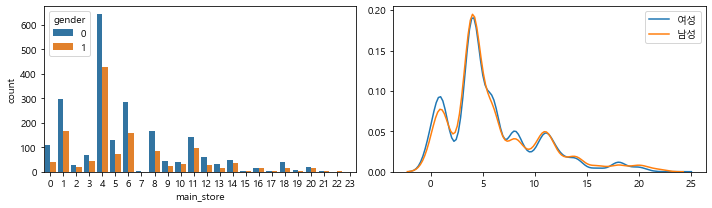

```python
figure, ax = plt.subplots(1, 2, figsize=(10, 3))

sns.countplot(data=f, x='main_store', hue='gender', ax=ax[0])
sns.kdeplot(f.query('gender==0').main_store, label = '여성', ax=ax[1])
sns.kdeplot(f.query('gender==1').main_store, label = '남성', ax=ax[1])

plt.tight_layout()
plt.show()
```

방문 지점의 수

```
- 방문 지점수가 남성은 1이 여성보다 높지만 여성은 2와 3에서 남성보다 높다.  큰 차이의 비율차는 아니지만 여성이 남성보다 방문 지점의 수가 더 많다
```

```python
f = tr.groupby('cust_id')['store_nm'].nunique().reset_index().rename(columns={'store_nm':'stores_count'})

f['gender'] = y_train['gender']
```

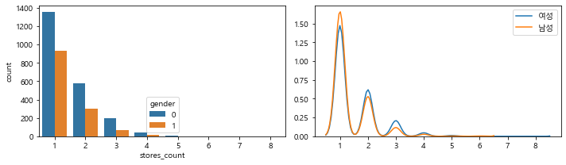

```python
figure, ax = plt.subplots(1, 2, figsize=(10, 3))

sns.countplot(data=f, x='stores_count', hue='gender', ax=ax[0])
sns.kdeplot(f.query('gender==0').stores_count, label = '여성', ax=ax[1])
sns.kdeplot(f.query('gender==1').stores_count, label = '남성', ax=ax[1])

plt.tight_layout()
plt.show()
```

많이 방문한 지점들 best-12 순위별 방문비율

```
- 각 지점마다 그림과 같이 방문데이터는 여성이 많아도 남성들이 해당 지점마다 확률비율이 다르므로 피쳐로 채택
- 방문 지점마다 모두 그림을 그리고 싶었지만 kdeplot의 선택된 kde가 bandwidth가 0인 것들이 있어서 대표적으로 하나만 그렸다
```

- top-12가 전체 24개의 점포중 91% 데이터를 차지한다

```python
## 전체의 90프로를 넘게 차지하는 12개의 점포 데이터

print(tr.store_nm.value_counts()[:12].sum() / tr.store_nm.value_counts().sum())
```

```
0.9145704384407165
```

```python
## top-12에 해당하는 지점들

top12store = tr.store_nm.value_counts()[:12].index.tolist()

print(top12store)
```

```
['본  점', '분당점', '잠실점', '부산본점', '일산점', '노원점', '광주점', '영등포점', '강남점', '부평점', '청량리점', '대전점']
```

```python
# 고객별 전체방문일수
total_visits = tr.groupby('cust_id')['tran_date'].nunique()
# 고객별 점포별 방문일수
temp_storepivot = pd.pivot_table(tr.query('store_nm in @top12store'), index='cust_id', columns='store_nm', values='tran_date', aggfunc=(lambda x: x.nunique()), fill_value=0)

# 칼럼명 영문화
engname = temp_storepivot.columns.tolist()
newname = [str(i*10)+'_department' for i in range(len(engname))]
temp_storepivot = temp_storepivot.rename(columns=dict(zip(engname, newname)))

# 고객별 점포별 방문비율
for i in range(len(temp_storepivot.columns)):

     temp_storepivot.iloc[:,i] = temp_storepivot.iloc[:,i] / total_visits

f = temp_storepivot.reset_index()
f['gender'] = y_train['gender']
```

```python
bins = [0, 0.2, 0.4, 0.6, 0.8, 1.0]
labels = [0, 0.2, 0.4, 0.6, 0.8]

for i in range(12):

    f[f'{i}_department{i}'] = pd.cut(f[f'{i*10}_department'], bins= bins, labels = labels)
```

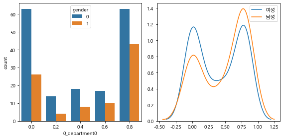

```python
figure, ax = plt.subplots(1, 2, figsize = (8, 4))
sns.countplot(data=f, x=f['0_department0'], hue='gender', ax=ax[0])

sns.kdeplot(f.query('gender==0')['0_department0'], label='여성', ax=ax[1])
sns.kdeplot(f.query('gender==1')['0_department0'], label='남성', ax=ax[1])

plt.tight_layout()
plt.show()
```

많이 방문한 지점들 best-12 순위별 구매금액비율

```
- 각 지점마다 그림과 같이 구매데이터는 여성이 많아도 남성들이 더 높은 구매금액비율을 보일때도 있고 밀도함수의 그래프도 지점마다 다르므로 피쳐로 채택
- 방문 지점마다 모두 그림을 그리고 싶었지만 kdeplot의 선택된 kde가 bandwidth가 0인 것들이 있어서 대표적으로 하나만 그렸다
```

```python
# 고객별 구매금액 총합
total_amount =  tr.groupby('cust_id')['amount'].sum()
# 고객별 점포별 구매금액
temp_storepivot = pd.pivot_table(tr.query('store_nm in @top12store'), index='cust_id', columns='store_nm', values='amount', aggfunc=sum, fill_value=0)

# 칼럼명 영문화
engname = temp_storepivot.columns.tolist()
newname = [str(i*10)+'_amount_ratio' for i in range(len(engname))]
temp_storepivot = temp_storepivot.rename(columns=dict(zip(engname, newname)))

# 고객별 점포별 구매금액비율
for i in range(len(temp_storepivot.columns)):

    temp_storepivot.iloc[:,i] = temp_storepivot.iloc[:,i] / total_amount

f = temp_storepivot.reset_index()
f['gender'] = y_train['gender']
```

```python
bins = [0, 0.1, 0.2, 0.3, 0.4, 0.5, 0.6, 0.7, 0.8, 0.9, 1.0]
labels = [0, 0.1, 0.2, 0.3, 0.4, 0.5, 0.6, 0.7, 0.8, 0.9]

for i in range(12):

    f[f'{i}_amount_ratio{i}'] = pd.cut(f[f'{i*10}_amount_ratio'], bins= bins, labels = labels)
```

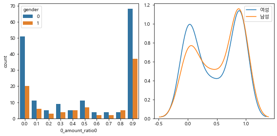

```python
figure, ax = plt.subplots(1, 2, figsize = (8, 4))
sns.countplot(data=f, x=f['0_amount_ratio0'], hue='gender', ax=ax[0])

sns.kdeplot(f.query('gender==0')['0_amount_ratio0'], label='여성', ax=ax[1])
sns.kdeplot(f.query('gender==1')['0_amount_ratio0'], label='남성', ax=ax[1])

plt.tight_layout()
plt.show()
```

많이 방문한 지점들 best-12 순위별 구매건수

```
- 구매건수를 5단위, 10단위로 묶어보았을 때 5단위가 좀더 완만하면서 남/녀 그래프 차이가 좀 더 나아서 5단위로 채택하였다
```

```python
# 고객별 점포별 구매건수
temp_storepivot = pd.pivot_table(tr.query('store_nm in @top12store'), index='cust_id', columns='store_nm', values='amount', aggfunc=np.size, fill_value=0)

# 칼럼명 영문화
engname = temp_storepivot.columns.tolist()
newname = [str(i*10)+'_num_of_pur' for i in range(len(engname))]
temp_storepivot = temp_storepivot.rename(columns=dict(zip(engname, newname)))

f = temp_storepivot.reset_index()
f['gender'] = y_train['gender']
```

```python
bins1 = [i*5 for i in range(195)]
bins2 = [i*10 for i in range(98)]
labels1 = [i for i in range(194)]
labels2 = [i for i in range(97)]
f[f'0_num_of_pur1'] = pd.cut(f['0_num_of_pur'], bins= bins1, labels = labels1)
f[f'0_num_of_pur2'] = pd.cut(f['0_num_of_pur'], bins= bins2, labels = labels2)
```

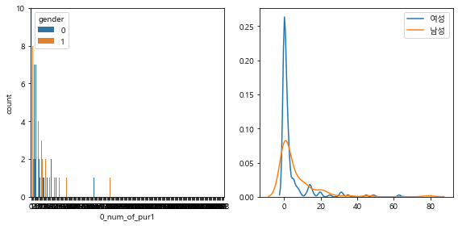

```python
figure, ax = plt.subplots(1, 2, figsize = (8, 4))
sns.countplot(data=f, x=f['0_num_of_pur1'], hue='gender', ax=ax[0])
ax[0].set_ylim(0, 10)
sns.kdeplot(f.query('gender==0')['0_num_of_pur1'], label='여성', ax=ax[1])
sns.kdeplot(f.query('gender==1')['0_num_of_pur1'], label='남성', ax=ax[1])

plt.tight_layout()
plt.show()
```

## ────────────────────────────────────────────────────────

### 4. 제품적 관점

- 구매추세 패턴
  - 주구매 상품1: goods_id
  - 주구매 상품2: gds_grp_nm
  - 주구매 상품3: gds_grp_mclas_nm
- 상품별 구매순서 -> 가장 먼저 방문하는 상품대분류명군
- 구매상품종류1(goods_id), 구매상품종류2(gds_grp_nm), 구매상품종류3(gds_grp_mclas_nm)
- Top-10 베스트 셀러(gds_grp_mclas_nm)에 대한 구매 금액/건수/여부
- 많이 구매한 상품소분류별 best-x 구매금액비율, 구매건수비율(3471 중 x)
- 많이 구매한 상품중분류별 best-y 구매금액비율, 구매건수비율(324 중 y)
- 많이 구매한 상품대분류별 best-z 구매금액비율, 구매건수비율(49 중 z)

구매추세패턴

주구매상품1

주구매 상품: 고객별 가장 많이 구매한 상품(goods_id)

```
 - 총 3471개 물품 중 3500명 고객이 각자 가장 많이 사는 물품들은 850개정도로 겹치는 물품들이 존재하였다
 - 겹치면서 많이 구매한 물품들에 있어서 남/녀를 구분할 수 있는 제품들이 있기 때문에 피쳐로 채택
```

```python
f = tr.groupby('cust_id')['goods_id'].agg([
    ('main_product_goods', lambda x: x.value_counts().index[0])
]).reset_index()

str_name = f.main_product_goods.unique().tolist()
num_name = [i*5 for i in range(len(str_name))]
f.main_product_goods = f.main_product_goods.map(dict(zip(str_name, num_name)))

f['gender'] = y_train['gender']

print('고객들이 많이 구매하는 제품 goods_id 수: ', f.main_product_goods.nunique())
```

```
고객들이 많이 구매하는 제품 goods_id 수:  846
```

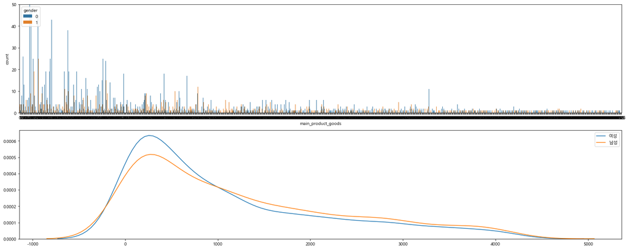

```python
figure, ax = plt.subplots(2, 1, figsize=(20, 8))

sns.countplot(data=f, x='main_product_goods', hue='gender', ax=ax[0])
ax[0].set_ylim(0,50)
sns.kdeplot(f.query('gender==0').main_product_goods, label = '여성', ax=ax[1])
sns.kdeplot(f.query('gender==1').main_product_goods, label = '남성', ax=ax[1])

plt.tight_layout()
plt.show()
```

주구매상품2

[output not shown]

```python
f = tr.groupby('cust_id')['gds_grp_nm'].agg([('main_product_nm', lambda x: x.value_counts().index[0])]).reset_index()

str_name = f.main_product_nm.unique().tolist()
num_name = [i*5 for i in range(len(str_name))]
f.main_product_nm = f.main_product_nm.map(dict(zip(str_name, num_name)))

f['gender'] = y_train['gender']

print('고객들이 많이 구매하는 제품 gds_grp_nm 수: ', f.main_product_nm.nunique())
```

```
고객들이 많이 구매하는 제품 gds_grp_nm 수:  191
```

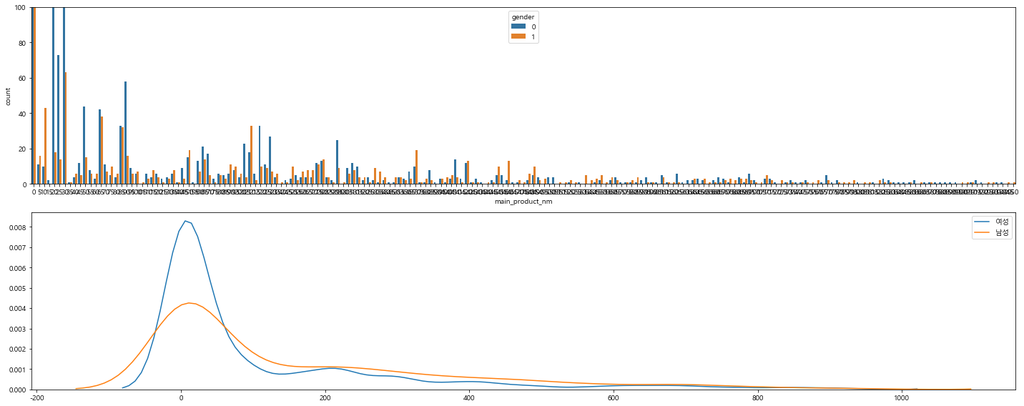

```python
figure, ax = plt.subplots(2, 1, figsize=(20, 8))

sns.countplot(data=f, x='main_product_nm', hue='gender', ax=ax[0])
ax[0].set_ylim(0,100)
sns.kdeplot(f.query('gender==0').main_product_nm, label = '여성', ax=ax[1])
sns.kdeplot(f.query('gender==1').main_product_nm, label = '남성', ax=ax[1])

plt.tight_layout()
plt.show()
```

주구매상품3

[output not shown]

```python
f = tr.groupby('cust_id')['gds_grp_mclas_nm'].agg([('main_product_mclas', lambda x: x.value_counts().index[0])]).reset_index()

# 상품대분류명군 문자를 숫자로 바꿔주기
str_name = f.main_product_mclas.unique().tolist()
num_name = [i*10 for i in range(len(str_name))]
f.main_product_mclas = f.main_product_mclas.map(dict(zip(str_name, num_name)))

f['gender'] = y_train['gender']

print('고객들이 많이 구매하는 제품 gds_grp_mclas_nm 수: ', f.main_product_mclas.nunique())
```

```
고객들이 많이 구매하는 제품 gds_grp_mclas_nm 수:  43
```

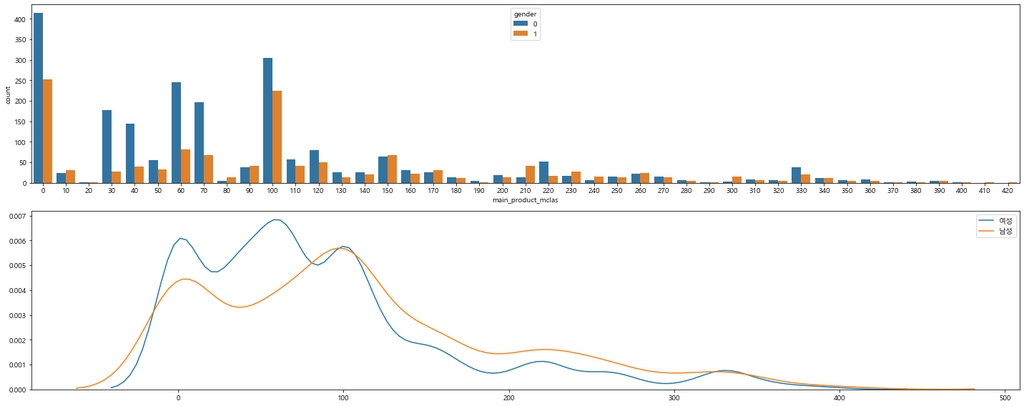

```python
figure, ax = plt.subplots(2, 1, figsize=(20, 8))

sns.countplot(data=f, x='main_product_mclas', hue='gender', ax=ax[0])
sns.kdeplot(f.query('gender==0').main_product_mclas, label = '여성', ax=ax[1])
sns.kdeplot(f.query('gender==1').main_product_mclas, label = '남성', ax=ax[1])

plt.tight_layout()
plt.show()
```

상품별 구매순서

```
- 고객이 가장 먼저 찾아가는 gds_grp_mclas_nm 를 보았다.
- 일단 피쳐로써 채택하지만 위의 주구매순서의 gds_grp_mclas_nm와의 상관관계 정도를 살펴보고 차후 제거될 수 있다
```

```python
temp_lst = []
for i in range(3500):
    temp_lst.append(tr.query(f'cust_id == {i}').drop_duplicates('tran_date')['gds_grp_mclas_nm'].value_counts().index[0])

f = pd.DataFrame({'cust_id': np.arange(3500)})
f['first_visit_place'] = temp_lst

# 상품대분류명군 문자를 숫자로 바꿔주기
str_name = f.first_visit_place.unique().tolist()
num_name = [i*5 for i in range(len(str_name))]
f.first_visit_place = f.first_visit_place.map(dict(zip(str_name, num_name)))

f['gender'] = y_train['gender']
```

```python
f.first_visit_place.nunique()
```

```
45
```

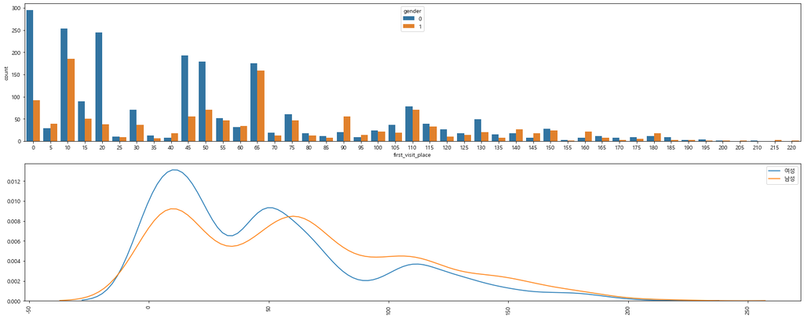

```python
figure, ax = plt.subplots(2, 1, figsize=(20, 8))

sns.countplot(data=f, x='first_visit_place', hue='gender', ax=ax[0])
plt.xticks(rotation=90)
sns.kdeplot(f.query('gender==0').first_visit_place, label = '여성', ax=ax[1])
sns.kdeplot(f.query('gender==1').first_visit_place, label = '남성', ax=ax[1])

plt.tight_layout()
plt.show()
```

구매상품종류1(goods_id), 구매상품종류2(gds_grp_nm), 구매상품종류3(gds_grp_mclas_nm)

```
- 대체적으로 여성들의 구매종류수가 더 많음을 알 수 있다 피쳐로 채택
- 하지만 나중에 피쳐간의 상관관계를 볼때 만약 너무 높다면 이중에 하나만 채택한다
```

```python
f = tr.groupby('cust_id').agg({
    'goods_id': [('num_pur_type1', lambda x: x.nunique())],
    'gds_grp_nm': [('num_pur_type2', lambda x: x.nunique())],
    'gds_grp_mclas_nm': [('num_pur_type3', lambda x: x.nunique())]
})

f.columns = f.columns.droplevel()  # 동일한 코드: f.columns = [j for _, j in f.columns]
f=f.reset_index()

f['gender'] = y_train['gender']
```

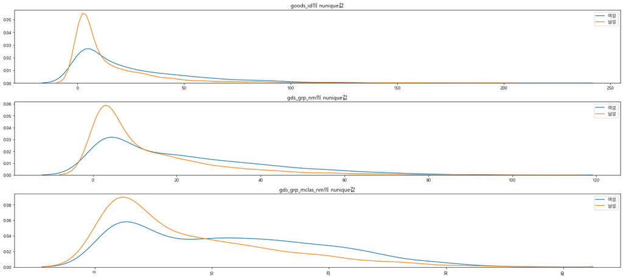

```python
figure , ax = plt.subplots(3, 1, figsize=(20,9))

for i in range(3):
    sns.kdeplot(f.query('gender==0')[f'num_pur_type{i+1}'], label='여성', ax=ax[i])
    sns.kdeplot(f.query('gender==1')[f'num_pur_type{i+1}'], label='남성', ax=ax[i])
ax[0].set_title('goods_id의 nunique값')
ax[1].set_title('gds_grp_nm의 nunique값')
ax[2].set_title('gds_grp_mclas_nm의 nunique값')
plt.xticks(rotation=90)
plt.tight_layout()
plt.show()
```

### 상품 분류별 top-x 구매금액비율 , 구매건수

- 상품분류별 중 90퍼센트 이상을 차지하는 상품들의 구매금액비율과 구매건수를 구한다
- 주구매상품에서 상품대분류, 중분류, 소분류에서 모두 차이가 났기 때문에 구체적으로 상품별로 구분하고자 생성하였다
- 나중에 train과 test에서 겹치는 부분을 뽑아내기 때문에 칼럼 수가 줄어든다.

  ```
   - goods_id(상품소분류별) top550 구매금액비율, 구매건수
   - gds_grp_nm(상품중분류별) top75 구매금액비율, 구매건수
   - gds_grp_mclas_nm(상품대분류별) top25 구매금액비율, 구매건수
  ```

많이 구매한 상품소분류별 best-x 구매금액비율, 구매건수(3471 중 x)

```python
total = tr.amount.sum()

## 전체 구매금액 중 goods_id top550이 전체의 90퍼센트 정도를 차지한다.

top550 = tr.groupby('goods_id')['amount'].sum().reset_index().sort_values('amount', ascending=False)[:550]

top550sum = top550['amount'].sum()

top550goods = top550['goods_id'].tolist()

print(top550sum / total)
```

```
0.9034186144204891
```

```python
totalsum = tr.groupby('cust_id')['amount'].sum()

temp_goodsdf = tr.query('goods_id in @top550goods')

## top550goods 구매금액비율
temp_goodspivot = pd.pivot_table(temp_goodsdf, index='cust_id', columns='goods_id', values='amount', aggfunc=sum, fill_value=0)

for i in range(len(temp_goodspivot.columns)):
        temp_goodspivot.iloc[:,i] = temp_goodspivot.iloc[:,i] / totalsum

f = temp_goodspivot.reset_index()


## top550goods 구매금액건수

temp_goodspivot = pd.pivot_table(temp_goodsdf, index='cust_id', columns='goods_id', values='amount', aggfunc=np.size, fill_value=0)

# 변수명이 겹치는 것을 막기 위해서 변수명을 다르게 바꿔주는 과정
oldname = temp_goodspivot.columns.tolist()
newname = [(str(i)+'_buy') for i in oldname]
temp_goodspivot = temp_goodspivot.rename(columns = dict(zip(oldname, newname)))

f2 = temp_goodspivot.reset_index() # 3258행
f = pd.merge(f, f2, how='outer').fillna(0)
```

많이 구매한 상품중분류별 best-y 구매금액비율, 구매건수비율(324 중 y)

```python
## 전체 구매금액
total = tr.amount.sum()

## 전체 구매금액 중 gds_grp_nm top75이 전체의 90퍼센트 정도를 차지한다.

top75 = tr.groupby('gds_grp_nm')['amount'].sum().reset_index().sort_values('amount', ascending=False)[:75]

top75sum = top75['amount'].sum()

top75goods = top75['gds_grp_nm'].tolist()

print(top75sum / total)
```

```
0.9099637919037719
```

```python
# 고객별 전체 구매금액
totalsum = tr.groupby('cust_id')['amount'].sum()

## top75goods 구매금액비율
temp_goodsdf = tr.query('gds_grp_nm in @top75goods')

temp_goodspivot = pd.pivot_table(temp_goodsdf, index='cust_id', columns='gds_grp_nm', values='amount', aggfunc=sum, fill_value=0)

# 변수명 영문화
kor_name = temp_goodspivot.columns.tolist()
newname = [str(i*3)+'grp_nm' for i in range(len(kor_name))]
temp_goodspivot = temp_goodspivot.rename(columns=dict(zip(kor_name, newname)))

for i in range(len(temp_goodspivot.columns)):
    temp_goodspivot.iloc[:,i] = temp_goodspivot.iloc[:,i] / totalsum

f = temp_goodspivot.reset_index()


## top75goods 구매금액건수

temp_goodspivot = pd.pivot_table(temp_goodsdf, index='cust_id', columns='gds_grp_nm', values='amount', aggfunc=np.size, fill_value=0)

# 변수명 영문화
kor_name = temp_goodspivot.columns.tolist()
newname = [str(i*3)+'grp_nm_buy' for i in range(len(kor_name))]
temp_goodspivot = temp_goodspivot.rename(columns=dict(zip(kor_name, newname)))

f2 = temp_goodspivot.reset_index()
```

많이 구매한 상품대분류별 best-z 구매금액비율, 구매건수비율(49 중 z)

```python
## 전체 구매금액
total = tr.amount.sum()

## 전체 구매금액 중 gds_grp_mclas_nm top25이 전체의 90퍼센트 정도를 차지한다.
top25 = tr.groupby('gds_grp_mclas_nm')['amount'].sum().reset_index().sort_values('amount', ascending=False)[:25]

top25sum = top25['amount'].sum()

top25goods = top25['gds_grp_mclas_nm'].tolist()

print(top25sum / total)
```

```
0.9232754143371885
```

```python
 # 고객별 전체 구매금액
totalsum = tr.groupby('cust_id')['amount'].sum()

## intersection25 구매금액비율
temp_goodsdf = tr.query('gds_grp_mclas_nm in @top25goods')

temp_goodspivot = pd.pivot_table(temp_goodsdf, index='cust_id', columns='gds_grp_mclas_nm', values='amount', aggfunc=sum, fill_value=0)

# 변수명 영문화
kor_name = temp_goodspivot.columns.tolist()
newname = [str(i*3)+'mclas_nm' for i in range(len(kor_name))]
temp_goodspivot = temp_goodspivot.rename(columns=dict(zip(kor_name, newname)))

for i in range(len(temp_goodspivot.columns)):
    temp_goodspivot.iloc[:,i] = temp_goodspivot.iloc[:,i] / totalsum

f = temp_goodspivot.reset_index()

## intersection25 구매건수

temp_goodspivot = pd.pivot_table(temp_goodsdf, index='cust_id', columns='gds_grp_mclas_nm', values='amount', aggfunc=np.size, fill_value=0)

# 변수명 영문화
kor_name = temp_goodspivot.columns.tolist()
newname = [str(i*3)+'mclas_nm_buy' for i in range(len(kor_name))]
temp_goodspivot = temp_goodspivot.rename(columns=dict(zip(kor_name, newname)))

f2 = temp_goodspivot.reset_index()
```

## ────────────────────────────────────────────────────────

### 5. 기타적 관점

휴면(또는 이탈) 여부

```
- 여성과 남성 모두 데이터량이 비슷하였으며 주관적 생각에 의해 휴면고객이라 생각된 사람들 중에서 남/녀를 구별할 수 없었으므로 피쳐 제거
```

- 롯데백화점에서 휴면회원은 일년이상 이용하지 않은 고객이다
- 하지만 데이터가 2007년만 있으니, 일년동안 방문이 2번이하인 사람들이 휴면 또는 이탈여부가 있다고 보고 1 그렇지 않은 사람들을 0 으로.
  - 3번이상 5번이하의 고객들은 띄엄띄엄 방문하는 경향이 있었으며 주기도 10개월이하로 단골은 아니지만 이탈위험이 크게 느껴지진 않았다.(주관)

```python
## 총 방문일수가 2일 이하인 고객들
f = tr.groupby('cust_id')['tran_date'].nunique().reset_index().query('tran_date in [1, 2]')

f['leave_risk'] = [5 for i in range(len(f.tran_date))]

f = f[['cust_id', 'leave_risk']]

f['gender'] = y_train['gender']
```

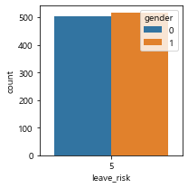

```python
plt.figure(figsize=(3,3))
sns.countplot(data=f, x='leave_risk', hue='gender')

plt.tight_layout()
plt.show()
```

## ────────────────────────────────────────────────────────

### 6. 피쳐 상관관계

EDA 이후 채택되지 않은 피쳐들 제거

가격: 가격 선호도, 환불금액, 환불건수, 내점 당 구매액,  
시간: 월별 방문비율, 월별 구매건수, 월초, 월중, 월말 선호 방문때, 최근 3개월, 6개월, 12개월 구매금&구매건수  
장소: 주구매지점  
제품: Top-10 베스트 셀러(gds_grp_mclas_nm)에 대한 구매 금액/건수/여부(겹쳐서)  
기타: 휴면(또는 이탈)여부

```python
df = pd.read_csv('X_train_after_eda.csv', encoding='cp949')
```

같은 관점의 피쳐끼리 상관관계

```
- 같은 관점끼리 히트맵을 그려 상관관계가 0.7이상인 칼럼들을 모두 제거하였다
- 밑의 히트맵은 상관관계가 높았던 칼럼들의 제거 이후에 그린 히트맵이다
```

상관관계가 0.7이상으로 높아서 삭제한 칼럼들

가격: none  
시간: 월초, 월중, 월말 구매건수&구매비율, 요일별 구매건수, 주말 구매건수, 1월 구매비율, 수목금 구매비율  
장소: top12 방문비율  
제품: 소중대분류에서 상관관계 높은 상품 162개  
기타: none

```python
df = pd.read_csv('X_train_after_eda.csv', encoding='cp949')
```

```python
high_corr_cols = []

delCol1 = ['0to10_10unit', '11to20_20unit', '21to31_30unit','4_buy', '3_buy', '2_buy','0_buy','6_buy','5_buy','1_buy','weekend_buy2', '1_month_amount','2_month_amount','0to10_amount','0to10_amount','11to20_20unit','21to31_amount','3_amount','2_amount','4_amount']

delCol2 = ['0_visits0','1_visits1','2_visits2','3_visits3','4_visits4','5_visits5','6_visits6','7_visits7','8_visits8','9_visits9','10_visits10']

delCol3 = ['num_pur_type2', 'num_pur_type3']

delCol4 = ['241192', '262241', '263107', '542166', '740195', '742196', '241125_buy', '241133_buy', '241192_buy', '262141_buy', '262241_buy', '263107_buy', '342111_buy', '342132_buy', '562128_buy', '563196_buy', '740195_buy', '742196_buy', '96grp_nm_buy', '141grp_nm_buy', '165grp_nm_buy', '189grp_nm_buy', '195grp_nm_buy', '18mclas_nm_buy', '48mclas_nm_buy', '63mclas_nm_buy', '56108', '607138', '811110', '66123_buy', '77152_buy', '303126_buy', '321103_buy', '542192_buy', '607138_buy', '39grp_nm', '45grp_nm', '192grp_nm', '12grp_nm_buy', '15grp_nm_buy', '36grp_nm_buy', '45grp_nm_buy', '111grp_nm_buy', '3mclas_nm', '15mclas_nm', '15mclas_nm_buy', '21mclas_nm_buy', '45mclas_nm_buy', '26165', '66123', '68273', '73119', '125156', '127118', '127128', '127131', '127141', '128128', '128131', '173197', '204125', '204128', '204152', '204162', '206101', '208102', '208110', '208121', '208140', '222102', '245105', '245117', '245140', '261188', '275131','303125', '303140', '321106', '322103', '322154', '322158', '331101', '342150', '361106', '361206', '365219', '530157', '530232', '541153', '542266', '552110', '562117', '562132', '563112', '611150', '611162', '611189', '613151', '624165', '630134', '647101','663102', '663106', '663108', '663110', '663111', '735105', '735124', '737101', '740112', '740120', '740130', '740131', '740153', '740177', '740178', '740215', '808194', '811115', '811127', '811156', '813150', '823165', '37140_buy', '56108_buy', '73151_buy', '127109_buy', '262161_buy', '303109_buy', '303110_buy', '303146_buy', '303209_buy', '303246_buy', '322111_buy', '322211_buy', '562113_buy', '611150_buy', '618101_buy', '647101_buy', '663106_buy', '731196_buy', '735124_buy', '9grp_nm', '42grp_nm', '54grp_nm', '72grp_nm', '78grp_nm', '93grp_nm', '135grp_nm', '198grp_nm', '42grp_nm_buy', '54grp_nm_buy', '72grp_nm_buy', '78grp_nm_buy', '93grp_nm_buy', '108grp_nm_buy', '117grp_nm_buy', '135grp_nm_buy', '138grp_nm_buy', '171grp_nm_buy', '192grp_nm_buy', '198grp_nm_buy']

high_corr_cols = delCol1 + delCol2 + delCol3 + delCol4

print('1차 상관관계 높은 칼럼 제거 개수: ', len(high_corr_cols))

df2 = df.drop(columns=high_corr_cols)
```

```
1차 상관관계 높은 칼럼 제거 개수:  195
```

```python
df = df.drop('cust_id', axis=1)

price_df = df.iloc[:, :6]

time_df = df.loc[:,'total_visit2':'weekend_buy2']
time_df = time_df.drop(columns=delCol1)

store_df = df.loc[:,'stores_count':'10_num_of_pur10']
store_df = store_df.drop(columns=delCol2)

product_df = df.loc[:,'main_product_goods':'num_pur_type3']
product_df = product_df.drop(columns=delCol3)

product_df2 = df.loc[:,'num_pur_type3':]
product_df2 = product_df2.drop(columns=delCol4)
```

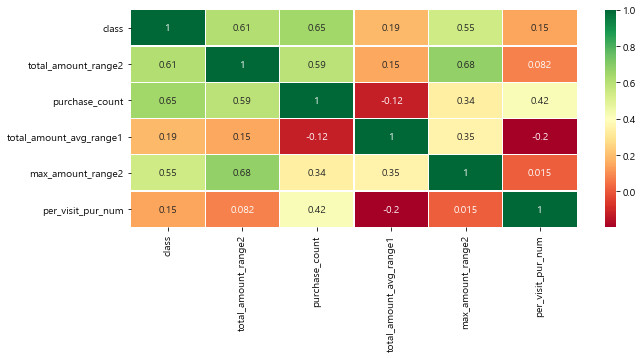

```python
plt.figure(figsize=(10,4))
sns.heatmap(price_df.corr(), annot=True, cmap='RdYlGn', linewidths=0.2)
plt.show()
```

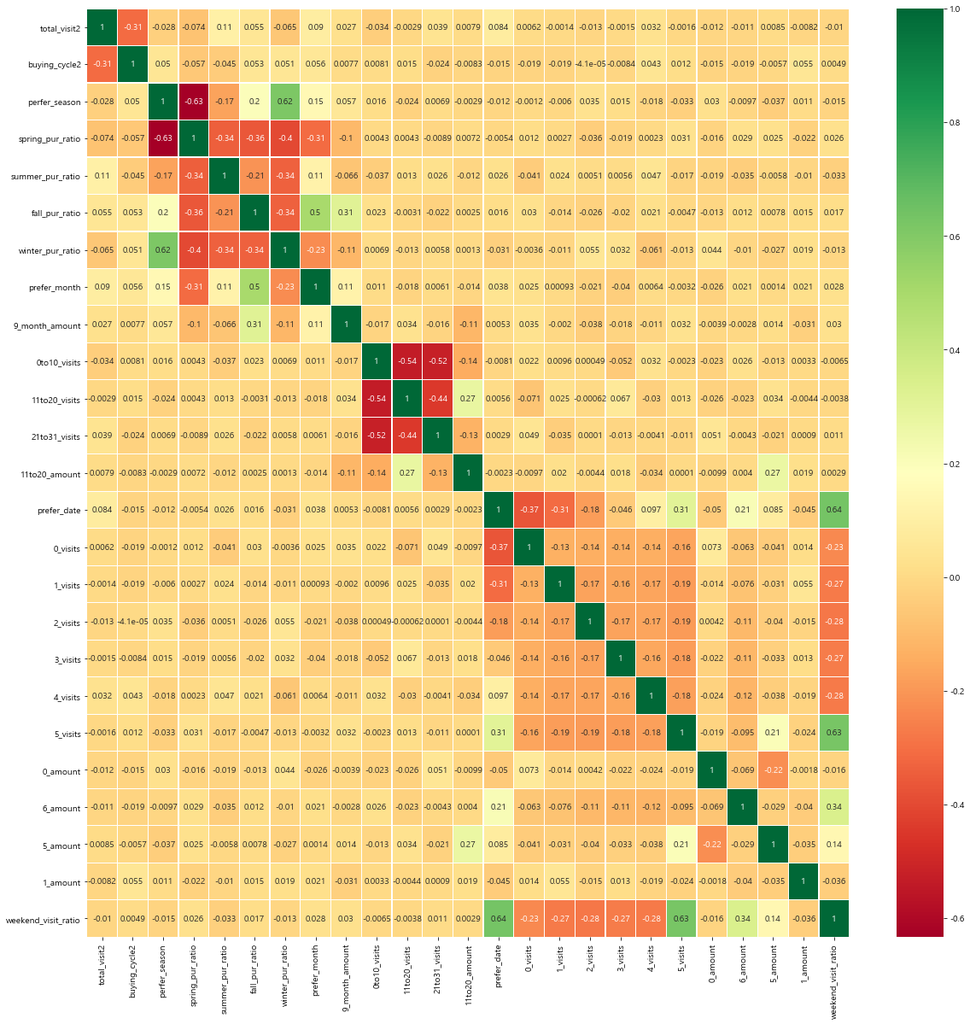

```python
plt.figure(figsize=(20,20))
sns.heatmap(time_df.corr(), annot=True, cmap='RdYlGn', linewidths=0.2)
plt.show()
```

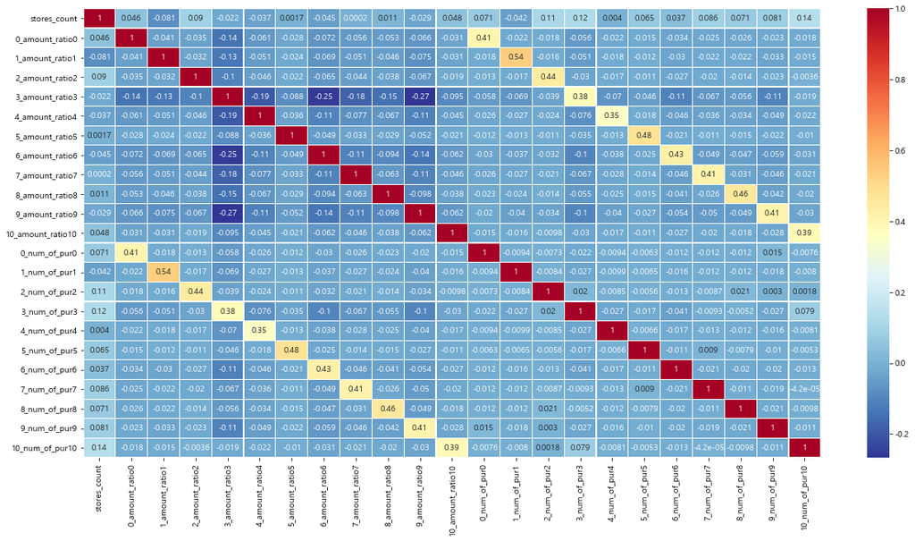

```python
plt.figure(figsize=(20,10))
sns.heatmap(store_df.corr(), annot=True, cmap='RdYlBu_r', linewidths=0.2)
plt.show()
```

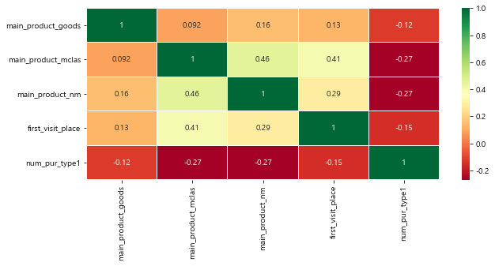

```python
plt.figure(figsize=(10,4))
sns.heatmap(product_df.corr(), annot=True, cmap='RdYlGn', linewidths=0.2)
plt.show()
```

모든 피쳐끼리 상관관계

```
- 모든 피쳐중 높은 상관관계를 갖는 것으로 보이는 칼럼 중 3개 칼럼 제거
- 밑의 히트맵은 상관관계가 높았던 칼럼이 있던 모습이었음.
- 3개 칼럼 제거이후 1000개가 넘는 피쳐끼리 상관관계가 0.7이상으로 높은 피쳐는 없었음
```

```python
df3 = df2.drop(columns=['purchase_count','total_visit2','6_num_of_pur6'])
```

```python
corrdf = (df2.corr() >= 0.7).sum().reset_index().rename(columns={'index':'cols',0:'corrCount'})

corrlst = corrdf.query('corrCount > 1')['cols'].unique().tolist()
```

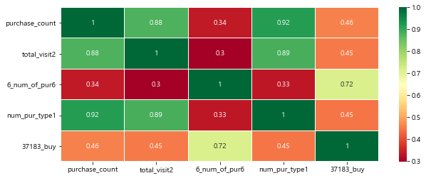

```python
plt.figure(figsize=(10,4))
sns.heatmap(df2[corrlst].corr(), annot=True, cmap='RdYlGn', linewidths=0.2)
plt.show()
```

## ch.3 modeling

```python
X_train = pd.read_csv('X_train_after_corr.csv',encoding='cp949')
y_train = pd.read_csv('tr_train_y.csv', encoding='cp949')
X_test = pd.read_csv('X_test_after_corr.csv', encoding='cp949')

y_train.drop(columns='cust_id', inplace=True)
```

### Basic models predictions with Stratied KFold

```
 - 9개의 모델별 피쳐에 대한 기본적인 성능을 확인한다
 - 불균형 데이터이기 때문에 기본적으로 모델 모두 Stratied KFold로 학습시켜보았다
 - 기본적인 성능확인 후 훈련점수가 0.6조차 되지 않는 SVM인 SVC과 neural network인 mlp는 튜닝하지 않기로 하였고
    또한 앙상블 할때 유의할점인 모델간 유사성능을 생각해서 knn와 logreg또한 튜닝대상에서 제외하였다
```

```python
rf = RandomForestClassifier()
extra = ExtraTreesClassifier()
knn = KNeighborsClassifier()
logreg = LogisticRegression()
svm = SVC()
gbm = GradientBoostingClassifier()
lgbm = LGBMClassifier()
xgb = XGBClassifier()
mlp = MLPClassifier()

models = [rf, extra, knn, logreg, svm, gbm, lgbm, xgb, mlp]
```

```python
# 모델별로 총 12개의 모델을 평균내어 예측한다


for model in models:

    lucky_seed = [2533,5066,9538]

    cv_scores = []

    for rs in lucky_seed:

        skf = StratifiedKFold(n_splits=4 , shuffle=False, random_state=rs)

        scores = cross_val_score(model, X_train, y_train, scoring='roc_auc', cv = skf)

        cv_scores.append(scores)

    print(f'{model.__class__.__name__}, \ncv성능들: {cv_scores}\n최고성능: {max([score for scoreArr in cv_scores for score in scoreArr])}\n평균성능: {np.mean(cv_scores)}\n')
```

```
RandomForestClassifier,
cv성능들: [array([0.73135097, 0.74584711, 0.7570755 , 0.75184264]), array([0.72808878, 0.73529232, 0.76617734, 0.74019395]), array([0.72994812, 0.7410596 , 0.75494895, 0.74365098])]
최고성능: 0.7661773383657883
평균성능: 0.7437896871787449

ExtraTreesClassifier,
cv성능들: [array([0.73545376, 0.7300344 , 0.74130454, 0.7449759 ]), array([0.72824187, 0.73468831, 0.74581093, 0.74230936]), array([0.73334391, 0.73308227, 0.74105682, 0.74934311])]
최고성능: 0.7493431087656014
평균성능: 0.7383037639496606

KNeighborsClassifier,
cv성능들: [array([0.59620673, 0.59760402, 0.61246201, 0.60452086]), array([0.59620673, 0.59760402, 0.61246201, 0.60452086]), array([0.59620673, 0.59760402, 0.61246201, 0.60452086])]
최고성능: 0.6124620060790273
평균성능: 0.6026984034202879

LogisticRegression,
cv성능들: [array([0.61468319, 0.63398354, 0.64344166, 0.62414131]), array([0.61468319, 0.63398354, 0.64344166, 0.62414131]), array([0.61468319, 0.63398354, 0.64344166, 0.62414131])]
최고성능: 0.6434416647182605
평균성능: 0.6290624269347673

SVC,
cv성능들: [array([0.57171805, 0.57515281, 0.55562978, 0.56474832]), array([0.57171805, 0.57515281, 0.55562978, 0.56474832]), array([0.57171805, 0.57515281, 0.55562978, 0.56474832])]
최고성능: 0.5751528107151207
평균성능: 0.5668122404444594

GradientBoostingClassifier,
cv성능들: [array([0.73248104, 0.73591859, 0.75691128, 0.74461405]), array([0.73292083, 0.73584065, 0.75616531, 0.74633978]), array([0.73187982, 0.73525613, 0.7557979 , 0.74523754])]
최고성능: 0.7569112751483572
평균성능: 0.7424469105700108

LGBMClassifier,
cv성능들: [array([0.72064309, 0.732623  , 0.7522685 , 0.74272688]), array([0.72064309, 0.732623  , 0.7522685 , 0.74272688]), array([0.72064309, 0.732623  , 0.7522685 , 0.74272688])]
최고성능: 0.7522685015086231
평균성능: 0.7370653662446975

XGBClassifier,
cv성능들: [array([0.71106249, 0.71628979, 0.7236659 , 0.73194384]), array([0.71106249, 0.71628979, 0.7236659 , 0.73194384]), array([0.71106249, 0.71628979, 0.7236659 , 0.73194384])]
최고성능: 0.7319438413663336
평균성능: 0.7207405056949131

MLPClassifier,
cv성능들: [array([0.61925916, 0.5756594 , 0.54313215, 0.53253282]), array([0.564701  , 0.58788982, 0.53843927, 0.56185911]), array([0.6712315 , 0.53192046, 0.55722469, 0.66606266])]
최고성능: 0.6712315040582517
평균성능: 0.5791593369480909
```

### Tuned models predictions with Stratified KFold

RandomSearch + Stratified KFold

```python
lucky_seed = [2533,5066,9538]  # 각 모델별 3개의 튜닝된 모델을 뽑아낸다

clfs_tuned = []  # 튜닝된 모델을 저장

for seed in lucky_seed:

    clfs = [
    (RandomForestClassifier(random_state=seed, n_jobs=-1),
     {'criterion': ['gini', 'entropy'],
      'n_estimators': [50, 70, 90, 110],
      'max_depth': [3, 5, 7,10],
      'max_features': [0.8,0.85,0.9]}
    ),
    (ExtraTreesClassifier(random_state=seed, n_jobs=-1),
        {'n_estimators': [50, 75, 100, 125],
            'max_depth': [3,5,7,10],
            'max_features': [0.8,0.9,0.95],
            'min_samples_split': [2,3,5],
            'min_samples_leaf': [1,3,5]}
    ),
    (GradientBoostingClassifier(random_state=seed),
        {'learning_rate': [0.01, 0.5, 1.0, 2.0],
         'n_estimators' : [100,125,150,175,200],
         'max_depth' : [3,4,5,6,7],
         'min_samples_split' : [0.75, 0.9],
         'subsample' : [0.8,0.9,0.95]}
    ),
    (LGBMClassifier(random_state=seed, objective='binary', n_jobs=-1),
        {'learning_rate': np.arange(0.1, 0.6, 0.1),
         'n_estimators': [100,125,150,175,200],
         'max_depth': [3,5,7,9],
         'min_child_weight': [3,8,13],
         'subsample': [0.75,0.85,0.95]}
    ),
    (XGBClassifier(random_state=seed, n_jobs=-1),
        {'learning_rate': [0.05,0.35,0.65,1.0],
         'n_estimators': [100,125,150,175,200],
         'max_depth': [3,5,7,9],
         'min_child_weight': [3,8,13],
         'subsample': [0.75, 0.85, 0.95],
         'gamma': [0,2,4],}
    )
    ]


    for clf, param_grid in tqdm(clfs):

        # 파라미터 서치
        rs = RandomizedSearchCV(clf, param_distributions = param_grid, scoring='roc_auc', random_state=seed, n_jobs=-1)

        # 모델 훈련
        scores = cross_val_score(rs, X_train, y_train, scoring='roc_auc', cv = 4, n_jobs=-1)

        # 모델 이름
        clf_name = type(clf).__name__

        # 모델 성능저장
        clf_score = max(scores)

        # 모델, 모델성능 확인
        print(f'모델: {clf_name:30} 성능: {clf_score}')

        # 튜닝된 모델을 튜닝된 모델 리스트에 추가
        clfs_tuned.append((clf_name, rs, clf_score))
```

```
모델: RandomForestClassifier         성능: 0.7436342785886859
```

```
모델: ExtraTreesClassifier           성능: 0.745276506674683
```

```
모델: GradientBoostingClassifier     성능: 0.741883496442767
```

```
모델: LGBMClassifier                 성능: 0.757910529187125
```

```
모델: XGBClassifier                  성능: 0.7613759087923222
```

```
모델: RandomForestClassifier         성능: 0.7500361846866406
```

```
모델: ExtraTreesClassifier           성능: 0.7464873019584266
```

```
모델: GradientBoostingClassifier     성능: 0.745666187915428
```

```
모델: LGBMClassifier                 성능: 0.7494544462629569
```

```
모델: XGBClassifier                  성능: 0.765712504314328
```

```
모델: RandomForestClassifier         성능: 0.7467238941403076
```

```
모델: ExtraTreesClassifier           성능: 0.7427602792344433
```

```
모델: GradientBoostingClassifier     성능: 0.5
```

```
모델: LGBMClassifier                 성능: 0.7494544462629569
```

```
모델: XGBClassifier                  성능: 0.7627509268846655
```

BaysianOptimization + Stratified KFold

```python
BO_tuned_clfs = []
```

RF

```python
# 하이퍼 파라미터 범위

pbounds = { 'n_estimators': (50,250),
            'max_depth': (3,10), # 나무의 범위를 넓게 주었기에 과적합을 막고자 깊이를 10이상으론 올라가지 않도록 하였다
            'max_features': (0.8,0.95),
            'min_samples_leaf': (1, 10)}

def rf_opt(n_estimators, max_depth, max_features, min_samples_leaf):

    params = {
        'n_estimators' : int(round(n_estimators)),
        'max_depth' : int(round(max_depth)),
        'min_samples_leaf' : int(round(min_samples_leaf))
    }

    rf = RandomForestClassifier(**params, n_jobs=-1, random_state=50)

    skf = StratifiedKFold(n_splits=4 , shuffle=False, random_state=50)

    score = cross_val_score(rf, X_train, y_train, scoring='roc_auc', cv=skf, n_jobs=-1)

    return np.mean(score)


BO_rf = BayesianOptimization(f = rf_opt, pbounds = pbounds, random_state=0)
```

```python
BO_rf.maximize(init_points=15, n_iter=20)
```

```
|   iter    |  target   | max_depth | max_fe... | min_sa... | n_esti... |
-------------------------------------------------------------------------
|  1        |  0.7351   |  6.842    |  0.9073   |  6.425    |  159.0    |
|  2        |  0.7299   |  5.966    |  0.8969   |  4.938    |  228.4    |
|  3        |  0.7413   |  9.746    |  0.8575   |  8.126    |  155.8    |
|  4        |  0.7343   |  6.976    |  0.9388   |  1.639    |  67.43    |
|  5        |  0.7072   |  3.142    |  0.9249   |  8.003    |  224.0    |
|  6        |  0.7434   |  9.85     |  0.9199   |  5.153    |  206.1    |
|  7        |  0.7178   |  3.828    |  0.896    |  2.29     |  238.9    |
|  8        |  0.7355   |  6.653    |  0.8622   |  3.381    |  204.8    |
|  9        |  0.7314   |  6.193    |  0.8853   |  1.169    |  173.5    |
|  10       |  0.7341   |  7.285    |  0.8925   |  9.494    |  186.4    |
|  11       |  0.7288   |  5.517    |  0.8656   |  7.279    |  62.05    |
|  12       |  0.7372   |  7.667    |  0.9006   |  2.893    |  75.79    |
|  13       |  0.7242   |  5.208    |  0.8546   |  6.132    |  137.7    |
|  14       |  0.7418   |  9.919    |  0.8153   |  2.88     |  82.26    |
|  15       |  0.7358   |  7.572    |  0.838    |  5.197    |  98.89    |
|  16       |  0.744    |  9.994    |  0.871    |  1.549    |  248.3    |
|  17       |  0.7439   |  9.891    |  0.8952   |  1.539    |  226.9    |
|  18       |  0.7394   |  9.994    |  0.9179   |  1.328    |  50.69    |
|  19       |  0.7433   |  9.937    |  0.8466   |  1.411    |  194.2    |
|  20       |  0.7363   |  9.961    |  0.8645   |  9.814    |  85.66    |
|  21       |  0.7405   |  9.907    |  0.8915   |  9.514    |  247.5    |
|  22       |  0.7424   |  9.597    |  0.8478   |  1.013    |  115.3    |
|  23       |  0.7433   |  9.988    |  0.8464   |  1.015    |  151.1    |
|  24       |  0.7439   |  9.993    |  0.8244   |  3.288    |  238.4    |
|  25       |  0.7419   |  9.899    |  0.9096   |  1.628    |  94.2     |
|  26       |  0.7438   |  9.975    |  0.8456   |  1.036    |  211.9    |
|  27       |  0.7351   |  9.464    |  0.9197   |  9.887    |  50.33    |
|  28       |  0.7412   |  9.998    |  0.9358   |  8.018    |  170.4    |
|  29       |  0.744    |  9.99     |  0.8377   |  1.982    |  236.1    |
|  30       |  0.744    |  9.988    |  0.9386   |  1.096    |  232.8    |
|  31       |  0.7402   |  9.944    |  0.8114   |  6.912    |  200.8    |
|  32       |  0.7435   |  9.95     |  0.8659   |  1.952    |  200.0    |
|  33       |  0.7441   |  9.933    |  0.8078   |  1.23     |  216.9    |
|  34       |  0.7424   |  9.989    |  0.8152   |  1.73     |  106.2    |
|  35       |  0.744    |  9.924    |  0.8006   |  1.348    |  227.4    |
=========================================================================
```

```python
# BO_rf.res  # 모든 성능 들어가있음
BO_rf.max
```

```
{'target': 0.7440504024850529,
 'params': {'max_depth': 9.933278993630882,
  'max_features': 0.8078216468158051,
  'min_samples_leaf': 1.2303522534421372,
  'n_estimators': 216.8513552784347}}
```

```python
max_params = BO_rf.max['params']

max_params['n_estimators'] = int(round(max_params['n_estimators']))
max_params['max_depth'] = int(round(max_params['max_depth']))
max_params['min_samples_leaf'] = int(round(max_params['min_samples_leaf']))

max_params
```

```
{'max_depth': 10,
 'max_features': 0.8078216468158051,
 'min_samples_leaf': 1,
 'n_estimators': 217}
```

```python
rf_clf = RandomForestClassifier(**max_params,  n_jobs=-1, random_state=42)

scores = cross_val_score(rf_clf, X_train, y_train, scoring='roc_auc', cv=4, n_jobs=-1)

print(scores)
print(f'최대성능: {max(scores)}\n평균성능: {np.mean(scores)}')

BO_tuned_clfs.append((rf_clf.__class__.__name__, rf_clf, max(scores)))
```

```
[0.72499081 0.73625817 0.73872429 0.73577942]
최대성능: 0.738724294955298
평균성능: 0.7339381742877183
```

XGB

```python
# 하이퍼 파라미터 범위

pbounds = { 'learning_rate': (0.05, 1.5),
            'n_estimators': (50, 250),
            'max_depth': (3,10),
            'subsample': (0.8,0.95),
            'colsample': (0.7,0.9),
            'gamma': (0, 5)}

def xgb_opt(learning_rate, n_estimators, max_depth, subsample, colsample, gamma):

    params = {
        'learning_rate': learning_rate,
        'n_estimators' : int(round(n_estimators)),
        'max_depth' : int(round(max_depth)),
        'subsample': subsample,
        'colsample': colsample,
        'gamma': gamma,
        'n_jobs' : -1
    }

    xgb = XGBClassifier(**params)

    skf = StratifiedKFold(n_splits=4 , shuffle=False, random_state=50)

    score = cross_val_score(xgb, X_train, y_train, scoring='roc_auc', cv=skf, n_jobs=-1)

    return np.mean(score)

BO_xgb = BayesianOptimization(f = xgb_opt, pbounds = pbounds, random_state=0)
```

```python
BO_xgb.maximize(init_points=15, n_iter=20)
```

```
|   iter    |  target   | colsample |   gamma   | learni... | max_depth | n_esti... | subsample |
-------------------------------------------------------------------------------------------------
|  1        |  0.687    |  0.8098   |  3.576    |  0.924    |  6.814    |  134.7    |  0.8969   |
|  2        |  0.6607   |  0.7875   |  4.459    |  1.447    |  5.684    |  208.3    |  0.8793   |
|  3        |  0.7437   |  0.8136   |  4.628    |  0.153    |  3.61     |  54.04    |  0.9249   |
|  4        |  0.6797   |  0.8556   |  4.35     |  1.469    |  8.594    |  142.3    |  0.9171   |
|  5        |  0.7229   |  0.7237   |  3.2      |  0.2579   |  9.613    |  154.4    |  0.8622   |
|  6        |  0.7067   |  0.7529   |  3.871    |  0.7114   |  6.979    |  53.76    |  0.8926   |
|  7        |  0.664    |  0.8224   |  3.085    |  1.418    |  7.773    |  121.9    |  0.8656   |
|  8        |  0.6864   |  0.8395   |  0.3011   |  1.017    |  7.694    |  92.08    |  0.8193   |
|  9        |  0.6868   |  0.7631   |  1.819    |  0.8768   |  6.07     |  247.7    |  0.8153   |
|  10       |  0.6997   |  0.7418   |  0.8065   |  0.997    |  4.773    |  143.3    |  0.8367   |
|  11       |  0.6808   |  0.7318   |  0.5519   |  1.002    |  3.967    |  89.32    |  0.8553   |
|  12       |  0.6674   |  0.8642   |  0.4855   |  1.265    |  3.673    |  245.3    |  0.8703   |
|  13       |  0.6761   |  0.8954   |  3.024    |  1.122    |  3.274    |  106.6    |  0.818    |
|  14       |  0.7153   |  0.7592   |  0.5936   |  0.5111   |  5.9      |  62.83    |  0.9039   |
|  15       |  0.7011   |  0.8133   |  1.327    |  0.8087   |  3.658    |  165.2    |  0.9394   |
|  16       |  0.7419   |  0.8494   |  0.2851   |  0.0801   |  3.037    |  50.4     |  0.8317   |
|  17       |  0.7392   |  0.9      |  0.0      |  0.05     |  10.0     |  218.8    |  0.9059   |
|  18       |  0.7256   |  0.7848   |  0.3318   |  0.2027   |  9.475    |  183.1    |  0.8391   |
|  19       |  0.7347   |  0.7041   |  4.863    |  0.1684   |  9.918    |  233.6    |  0.9131   |
|  20       |  0.7301   |  0.8604   |  0.24     |  0.2855   |  9.999    |  234.2    |  0.8879   |
|  21       |  0.7273   |  0.7842   |  0.05997  |  0.3593   |  9.824    |  161.1    |  0.9357   |
|  22       |  0.7451   |  0.7155   |  4.74     |  0.1306   |  3.349    |  71.72    |  0.9409   |
|  23       |  0.7421   |  0.7807   |  4.905    |  0.05153  |  8.042    |  77.97    |  0.948    |
|  24       |  0.7429   |  0.8694   |  4.921    |  0.07462  |  4.026    |  68.34    |  0.9219   |
|  25       |  0.7407   |  0.7137   |  4.939    |  0.07674  |  8.81     |  100.4    |  0.9063   |
|  26       |  0.7487   |  0.8549   |  3.952    |  0.1077   |  3.382    |  59.92    |  0.8213   |
|  27       |  0.742    |  0.7906   |  4.49     |  0.06048  |  3.238    |  62.05    |  0.9292   |
|  28       |  0.7391   |  0.7353   |  4.775    |  0.173    |  9.981    |  172.4    |  0.8494   |
|  29       |  0.7431   |  0.7026   |  4.802    |  0.09232  |  9.968    |  202.8    |  0.8021   |
|  30       |  0.739    |  0.845    |  4.715    |  0.1054   |  9.99     |  220.8    |  0.9358   |
|  31       |  0.7397   |  0.8342   |  4.99     |  0.1261   |  9.194    |  92.79    |  0.8736   |
|  32       |  0.7413   |  0.7852   |  4.874    |  0.06201  |  9.909    |  196.1    |  0.8066   |
|  33       |  0.7454   |  0.8012   |  4.289    |  0.05854  |  3.652    |  78.07    |  0.8198   |
|  34       |  0.7426   |  0.7707   |  5.0      |  0.05     |  3.0      |  50.0     |  0.8      |
|  35       |  0.6966   |  0.8601   |  4.882    |  0.9606   |  3.064    |  55.45    |  0.8579   |
=================================================================================================
```

```python
# BO_rf.res  # 모든 성능 들어가있음
BO_xgb.max
```

```
{'target': 0.7486632541723727,
 'params': {'colsample': 0.8548781179307093,
  'gamma': 3.951962120990985,
  'learning_rate': 0.10771697765265095,
  'max_depth': 3.381508388534084,
  'n_estimators': 59.92425445048091,
  'subsample': 0.821324376341919}}
```

```python
max_params = BO_xgb.max['params']

max_params['n_estimators'] = int(round(max_params['n_estimators']))
max_params['max_depth'] = int(round(max_params['max_depth']))

max_params
```

```
{'colsample': 0.8548781179307093,
 'gamma': 3.951962120990985,
 'learning_rate': 0.10771697765265095,
 'max_depth': 3,
 'n_estimators': 60,
 'subsample': 0.821324376341919}
```

```python
xgb_clf = XGBClassifier(**max_params)

scores = cross_val_score(xgb_clf, X_train, y_train, scoring='roc_auc', cv=4, n_jobs=-1)

print(scores)
print(f'최대성능: {max(scores)}\n평균성능: {np.mean(scores)}')

BO_tuned_clfs.append((xgb_clf.__class__.__name__, xgb_clf, max(scores)))
```

```
[0.73385885 0.74512342 0.76553158 0.75013917]
최대성능: 0.7655315808811249
평균성능: 0.7486632541723727
```

LGBM

```python
pbounds = { 'learning_rate': (0.05, 1.5),
            'n_estimators': (50, 250),
            'max_depth': (3,10),
            'subsample': (0.8,0.95),
            'colsample_bytree': (0.75,0.9),
            'num_leaves': (2,10),
            'min_child_weight': (1, 7)}


def lgbm_opt(learning_rate, n_estimators, max_depth, subsample, colsample_bytree, num_leaves, min_child_weight):

    params = {
        'learning_rate': learning_rate,
        'n_estimators' : int(round(n_estimators)),
        'max_depth' : int(round(max_depth)),
        'subsample': subsample,
        'colsample_bytree' : colsample_bytree,
        'num_leaves' : int(round(num_leaves)),
        'min_child_weight' : min_child_weight,
        'n_jobs' : -1
    }

    lgbm = LGBMClassifier(**params)

    skf = StratifiedKFold(n_splits=4 , shuffle=False, random_state=50)

    score = cross_val_score(lgbm, X_train, y_train, scoring='roc_auc', cv=skf, n_jobs=-1)

    return np.mean(score)

BO_lgbm = BayesianOptimization(f = lgbm_opt, pbounds = pbounds, random_state=1)
```

```python
BO_lgbm.maximize(init_points=15, n_iter=20)
```

```
|   iter    |  target   | colsam... | learni... | max_depth | min_ch... | n_esti... | num_le... | subsample |
-------------------------------------------------------------------------------------------------------------
|  1        |  0.7003   |  0.8126   |  1.094    |  3.001    |  2.814    |  79.35    |  2.739    |  0.8279   |
|  2        |  0.7135   |  0.8018   |  0.6253   |  6.772    |  3.515    |  187.0    |  3.636    |  0.9317   |
|  3        |  0.6975   |  0.7541   |  1.022    |  5.921    |  4.352    |  78.08    |  3.585    |  0.9201   |
|  4        |  0.7245   |  0.8952   |  0.5045   |  7.846    |  6.258    |  228.9    |  2.68     |  0.8059   |
|  5        |  0.6757   |  0.7755   |  1.323    |  3.688    |  3.527    |  241.6    |  6.265    |  0.9038   |
|  6        |  0.6961   |  0.7973   |  1.045    |  8.842    |  1.11     |  200.0    |  9.911    |  0.9122   |
|  7        |  0.696    |  0.7921   |  1.194    |  3.723    |  3.687    |  231.7    |  4.349    |  0.8432   |
|  8        |  0.747    |  0.7695   |  0.07808  |  7.752    |  2.27     |  103.1    |  5.933    |  0.808    |
|  9        |  0.7372   |  0.8361   |  0.2628   |  7.125    |  5.199    |  70.47    |  5.312    |  0.9042   |
|  10       |  0.7362   |  0.8121   |  0.1224   |  6.751    |  4.983    |  153.0    |  9.557    |  0.888    |
|  11       |  0.7419   |  0.8855   |  0.2493   |  3.975    |  5.844    |  129.5    |  3.323    |  0.9391   |
|  12       |  0.687    |  0.8022   |  1.139    |  8.082    |  6.3      |  174.7    |  8.008    |  0.8523   |
|  13       |  0.678    |  0.7905   |  1.349    |  5.997    |  6.789    |  182.7    |  6.974    |  0.8172   |
|  14       |  0.7024   |  0.8924   |  0.7024   |  7.049    |  3.449    |  97.41    |  9.227    |  0.8861   |
|  15       |  0.694    |  0.7504   |  0.9449   |  5.287    |  4.162    |  227.2    |  4.858    |  0.9363   |
|  16       |  0.6727   |  0.8596   |  1.5      |  10.0     |  1.0      |  50.0     |  10.0     |  0.95     |
|  17       |  0.7427   |  0.8103   |  0.376    |  3.592    |  5.392    |  50.37    |  2.146    |  0.8245   |
|  18       |  0.7478   |  0.8991   |  0.05     |  10.0     |  1.0      |  136.8    |  8.88     |  0.8      |
|  19       |  0.7365   |  0.8336   |  0.1692   |  9.528    |  1.201    |  249.2    |  2.594    |  0.8747   |
|  20       |  0.7372   |  0.9      |  0.05     |  3.0      |  1.0      |  148.2    |  2.0      |  0.95     |
|  21       |  0.7438   |  0.8594   |  0.0772   |  3.365    |  1.476    |  117.6    |  8.806    |  0.8      |
|  22       |  0.7392   |  0.7795   |  0.05     |  3.0      |  7.0      |  52.22    |  10.0     |  0.8041   |
|  23       |  0.7437   |  0.8735   |  0.1189   |  9.881    |  6.134    |  109.7    |  2.296    |  0.8263   |
|  24       |  0.7388   |  0.8872   |  0.07237  |  3.235    |  2.063    |  58.47    |  3.077    |  0.9293   |
|  25       |  0.7425   |  0.7676   |  0.07335  |  9.601    |  6.88     |  60.32    |  3.97     |  0.9211   |
|  26       |  0.7336   |  0.7555   |  0.6207   |  9.795    |  6.396    |  201.9    |  2.02     |  0.8829   |
|  27       |  0.7474   |  0.8952   |  0.1999   |  3.325    |  6.53     |  247.8    |  2.357    |  0.8476   |
|  28       |  0.7473   |  0.7714   |  0.1479   |  9.18     |  6.833    |  153.7    |  2.595    |  0.8599   |
|  29       |  0.7447   |  0.8897   |  0.2734   |  8.705    |  1.841    |  119.3    |  2.219    |  0.931    |
|  30       |  0.7352   |  0.75     |  0.05     |  3.0      |  1.0      |  114.4    |  2.0      |  0.8      |
|  31       |  0.7456   |  0.8704   |  0.07957  |  9.989    |  6.306    |  123.3    |  9.667    |  0.9262   |
|  32       |  0.7459   |  0.8881   |  0.1471   |  3.482    |  1.528    |  207.5    |  2.247    |  0.8965   |
|  33       |  0.7118   |  0.8816   |  1.092    |  9.086    |  6.327    |  248.1    |  2.252    |  0.8501   |
|  34       |  0.7398   |  0.8826   |  0.3123   |  9.923    |  2.043    |  213.3    |  2.386    |  0.8633   |
|  35       |  0.7374   |  0.7861   |  0.05321  |  9.831    |  5.283    |  134.3    |  2.265    |  0.9188   |
=============================================================================================================
```

```python
# BO_rf.res  # 모든 성능 들어가있음
BO_lgbm.max
```

```
{'target': 0.7478045637240167,
 'params': {'colsample_bytree': 0.8990715881548663,
  'learning_rate': 0.05,
  'max_depth': 10.0,
  'min_child_weight': 1.0,
  'n_estimators': 136.75237845794302,
  'num_leaves': 8.880048094469647,
  'subsample': 0.8000000102710303}}
```

```python
max_params = BO_lgbm.max['params']

max_params['n_estimators'] = int(round(max_params['n_estimators']))
max_params['max_depth'] = int(round(max_params['max_depth']))
max_params['num_leaves'] = int(round(max_params['num_leaves']))

max_params
```

```
{'colsample_bytree': 0.8990715881548663,
 'learning_rate': 0.05,
 'max_depth': 10,
 'min_child_weight': 1.0,
 'n_estimators': 137,
 'num_leaves': 9,
 'subsample': 0.8000000102710303}
```

```python
lgbm_clf = LGBMClassifier(**max_params)

scores = cross_val_score(lgbm_clf, X_train, y_train, scoring='roc_auc', cv=4, n_jobs=-1)

print(scores)
print(f'최대성능: {max(scores)}\n평균성능: {np.mean(scores)}')

BO_tuned_clfs.append((lgbm_clf.__class__.__name__, lgbm_clf, max(scores)))
```

```
[0.73915294 0.73978757 0.76511963 0.74715811]
최대성능: 0.7651196321409088
평균성능: 0.7478045637240167
```

ExtraTreeClassifier

```python
pbounds = { 'n_estimators': (50, 250),
            'max_depth': (3,10),
            'max_features': (0.8,0.95),
            'min_samples_split': (2, 5),
            'min_samples_leaf': (1, 5)
            }

def extra_opt(n_estimators, max_depth, max_features, min_samples_split, min_samples_leaf):

    params = {
        'n_estimators': int(round(n_estimators)),
        'max_depth': int(round(max_depth)),
        'max_features' : max_features,
        'min_samples_leaf': int(round(min_samples_leaf)),
        'min_samples_split': int(round(min_samples_split)),
        'n_jobs' : -1
    }

    extra = ExtraTreesClassifier(bootstrap = True, oob_score=True, **params)

    skf = StratifiedKFold(n_splits=4 , shuffle=False, random_state=50)

    score = cross_val_score(extra, X_train, y_train, scoring='roc_auc', cv=skf, n_jobs=-1)

    return np.mean(score)

BO_extra = BayesianOptimization(f = extra_opt, pbounds = pbounds, random_state=0)
```

```python
BO_extra.maximize(init_points=15, n_iter=20)
```

```
|   iter    |  target   | max_depth | max_fe... | min_sa... | min_sa... | n_esti... |
-------------------------------------------------------------------------------------
|  1        |  0.7371   |  6.842    |  0.9073   |  3.411    |  3.635    |  134.7    |
|  2        |  0.7401   |  7.521    |  0.8656   |  4.567    |  4.891    |  126.7    |
|  3        |  0.7392   |  8.542    |  0.8793   |  3.272    |  4.777    |  64.21    |
|  4        |  0.7332   |  3.61     |  0.803    |  4.33     |  4.334    |  224.0    |
|  5        |  0.7373   |  9.85     |  0.9199   |  2.846    |  4.342    |  73.65    |
|  6        |  0.7401   |  7.479    |  0.8215   |  4.779    |  3.566    |  132.9    |
|  7        |  0.7357   |  4.852    |  0.9161   |  2.825    |  3.705    |  53.76    |
|  8        |  0.7422   |  7.323    |  0.8918   |  3.468    |  4.831    |  186.4    |
|  9        |  0.7386   |  5.517    |  0.8656   |  3.791    |  2.181    |  183.4    |
|  10       |  0.7406   |  7.694    |  0.8316   |  1.516    |  2.946    |  122.7    |
|  11       |  0.7391   |  6.991    |  0.8658   |  4.953    |  2.306    |  91.78    |
|  12       |  0.7319   |  4.129    |  0.898    |  2.013    |  3.399    |  98.89    |
|  13       |  0.7304   |  4.113    |  0.8166   |  3.625    |  2.415    |  89.32    |
|  14       |  0.7338   |  5.581    |  0.9231   |  1.388    |  4.514    |  69.22    |
|  15       |  0.7423   |  9.835    |  0.8703   |  4.907    |  3.815    |  197.9    |
|  16       |  0.743    |  9.748    |  0.8993   |  1.275    |  2.032    |  249.4    |
|  17       |  0.7413   |  9.918    |  0.903    |  1.007    |  2.428    |  170.5    |
|  18       |  0.7453   |  9.997    |  0.8019   |  4.287    |  4.48     |  249.6    |
|  19       |  0.7443   |  9.738    |  0.8117   |  4.843    |  4.855    |  248.9    |
|  20       |  0.7449   |  9.948    |  0.8588   |  4.34     |  2.366    |  248.9    |
|  21       |  0.745    |  9.94     |  0.8966   |  4.985    |  4.206    |  247.2    |
|  22       |  0.7455   |  9.863    |  0.8295   |  4.89     |  2.278    |  165.7    |
|  23       |  0.7447   |  9.983    |  0.8702   |  4.665    |  2.513    |  246.4    |
|  24       |  0.7454   |  9.902    |  0.8374   |  4.757    |  4.921    |  174.0    |
|  25       |  0.7415   |  9.983    |  0.8215   |  4.742    |  2.16     |  164.5    |
|  26       |  0.7455   |  9.909    |  0.8945   |  4.693    |  4.86     |  245.7    |
|  27       |  0.7432   |  9.956    |  0.8542   |  2.904    |  4.729    |  247.6    |
|  28       |  0.7446   |  9.992    |  0.8816   |  4.899    |  3.016    |  220.1    |
|  29       |  0.7398   |  9.865    |  0.9462   |  4.974    |  4.647    |  209.5    |
|  30       |  0.7389   |  9.983    |  0.809    |  4.843    |  2.954    |  52.18    |
|  31       |  0.7439   |  9.854    |  0.8285   |  4.848    |  2.175    |  247.7    |
|  32       |  0.7429   |  9.984    |  0.8036   |  4.886    |  4.053    |  249.0    |
|  33       |  0.7428   |  9.999    |  0.9272   |  4.96     |  2.183    |  245.3    |
|  34       |  0.744    |  9.958    |  0.8534   |  4.795    |  4.989    |  140.6    |
|  35       |  0.7437   |  9.949    |  0.8404   |  4.738    |  4.948    |  161.7    |
=====================================================================================
```

```python
# BO_rf.res  # 모든 성능 들어가있음
BO_extra.max
```

```
{'target': 0.7454699555763384,
 'params': {'max_depth': 9.863393737026527,
  'max_features': 0.8294853548465777,
  'min_samples_leaf': 4.890311444140735,
  'min_samples_split': 2.277517807483899,
  'n_estimators': 165.7061462278227}}
```

```python
max_params = BO_extra.max['params']

max_params['n_estimators'] = int(round(max_params['n_estimators']))
max_params['max_depth'] = int(round(max_params['max_depth']))
max_params['min_samples_leaf'] = int(round(max_params['min_samples_leaf']))
max_params['min_samples_split'] = int(round(max_params['min_samples_split']))

max_params
```

```
{'max_depth': 10,
 'max_features': 0.8294853548465777,
 'min_samples_leaf': 5,
 'min_samples_split': 2,
 'n_estimators': 166}
```

```python
extra_clf = ExtraTreesClassifier(bootstrap = True, oob_score=True, **max_params)

scores = cross_val_score(extra_clf, X_train, y_train, scoring='roc_auc', cv=4, n_jobs=-1)

print(scores)
print(f'최대성능: {max(scores)}\n평균성능: {np.mean(scores)}')

BO_tuned_clfs.append((extra_clf.__class__.__name__, extra_clf, max(scores)))
```

```
[0.73101417 0.74456951 0.75585357 0.74091764]
최대성능: 0.7558535689234777
평균성능: 0.7430887248516428
```

GBM

```python
pbounds = { 'learning_rate': (0.05, 1.5),
            'n_estimators': (50, 250),
            'max_depth': (3,10),
            'subsample': (0.8,0.95),
            'min_samples_split': (2,5),
            'min_samples_leaf': (1,5)}


def gbm_opt(learning_rate, n_estimators, max_depth, subsample, min_samples_split, min_samples_leaf):

    params = {
        'learning_rate': learning_rate,
        'n_estimators' : int(round(n_estimators)),
        'max_depth' : int(round(max_depth)),
        'subsample': subsample,
        'min_samples_split' : int(round(min_samples_split)),
        'min_samples_leaf' : int(round(min_samples_leaf))
    }

    gbm = GradientBoostingClassifier(**params)

    skf = StratifiedKFold(n_splits=4 , shuffle=False, random_state=50)

    score = cross_val_score(gbm, X_train, y_train, scoring='roc_auc', cv=skf, n_jobs=-1)

    return np.mean(score)

BO_gbm = BayesianOptimization(f = gbm_opt, pbounds = pbounds, random_state=0)
```

```python
BO_gbm.maximize(init_points=15, n_iter=20)
```

```
|   iter    |  target   | learni... | max_depth | min_sa... | min_sa... | n_esti... | subsample |
-------------------------------------------------------------------------------------------------
|  1        |  0.6862   |  0.8458   |  8.006    |  3.411    |  3.635    |  134.7    |  0.8969   |
|  2        |  0.7021   |  0.6845   |  9.242    |  4.855    |  3.15     |  208.3    |  0.8793   |
|  3        |  0.6704   |  0.8737   |  9.479    |  1.284    |  2.261    |  54.04    |  0.9249   |
|  4        |  0.6436   |  1.178    |  9.09     |  4.914    |  4.397    |  142.3    |  0.9171   |
|  5        |  0.7165   |  0.2215   |  7.479    |  1.573    |  4.834    |  154.4    |  0.8622   |
|  6        |  0.7096   |  0.4336   |  8.42     |  2.825    |  3.705    |  53.76    |  0.8926   |
|  7        |  0.6776   |  0.9375   |  7.319    |  4.775    |  4.045    |  121.9    |  0.8656   |
|  8        |  0.6615   |  1.062    |  3.422    |  3.667    |  4.012    |  92.08    |  0.8193   |
|  9        |  0.6962   |  0.5074   |  5.546    |  3.281    |  3.316    |  247.7    |  0.8153   |
|  10       |  0.7029   |  0.3529   |  4.129    |  3.612    |  2.76     |  143.3    |  0.8367   |
|  11       |  0.7148   |  0.2805   |  3.773    |  3.625    |  2.415    |  89.32    |  0.8553   |
|  12       |  0.6352   |  1.24     |  3.68     |  4.352    |  2.288    |  245.3    |  0.8703   |
|  13       |  0.6052   |  1.466    |  7.234    |  3.957    |  2.118    |  106.6    |  0.818    |
|  14       |  0.6984   |  0.4794   |  3.831    |  2.272    |  3.243    |  62.83    |  0.9039   |
|  15       |  0.6854   |  0.8716   |  4.858    |  3.093    |  2.282    |  165.2    |  0.9394   |
|  16       |  0.7474   |  0.05     |  3.0      |  1.0      |  5.0      |  193.2    |  0.8      |
|  17       |  0.7341   |  0.05     |  10.0     |  1.0      |  5.0      |  229.8    |  0.8      |
|  18       |  0.7361   |  0.05     |  3.0      |  5.0      |  2.0      |  50.0     |  0.95     |
|  19       |  0.7325   |  0.05     |  10.0     |  1.0      |  2.0      |  188.1    |  0.8      |
|  20       |  0.7332   |  0.05     |  10.0     |  5.0      |  2.0      |  73.11    |  0.8045   |
|  21       |  0.6242   |  1.084    |  9.76     |  3.156    |  2.429    |  249.6    |  0.8152   |
|  22       |  0.7444   |  0.05     |  3.0      |  1.0      |  5.0      |  215.5    |  0.8      |
|  23       |  0.6218   |  1.5      |  3.0      |  1.0      |  5.0      |  250.0    |  0.8451   |
|  24       |  0.7325   |  0.05     |  10.0     |  5.0      |  5.0      |  181.1    |  0.8      |
|  25       |  0.7351   |  0.05     |  9.989    |  5.0      |  5.0      |  237.9    |  0.8      |
|  26       |  0.749    |  0.05     |  3.0      |  1.0      |  2.0      |  122.0    |  0.8157   |
|  27       |  0.7331   |  0.05     |  10.0     |  1.0      |  5.0      |  82.69    |  0.8      |
|  28       |  0.7264   |  0.1052   |  9.459    |  1.843    |  4.77     |  204.8    |  0.9345   |
|  29       |  0.742    |  0.05     |  3.0      |  1.0      |  5.0      |  133.2    |  0.95     |
|  30       |  0.7453   |  0.05     |  3.0      |  5.0      |  2.0      |  190.9    |  0.95     |
|  31       |  0.742    |  0.05     |  3.0      |  5.0      |  5.0      |  74.81    |  0.8      |
|  32       |  0.7488   |  0.05     |  3.0      |  1.0      |  5.0      |  178.1    |  0.8      |
|  33       |  0.7434   |  0.06511  |  3.436    |  4.774    |  4.311    |  226.1    |  0.8359   |
|  34       |  0.7315   |  0.05     |  10.0     |  1.0      |  2.0      |  125.3    |  0.95     |
|  35       |  0.7101   |  0.3686   |  4.126    |  2.65     |  4.754    |  50.31    |  0.8029   |
=================================================================================================
```

```python
# BO_rf.res  # 모든 성능 들어가있음
BO_gbm.max
```

```
{'target': 0.7489930915082891,
 'params': {'learning_rate': 0.05,
  'max_depth': 3.0,
  'min_samples_leaf': 1.0,
  'min_samples_split': 2.0,
  'n_estimators': 122.00588046248643,
  'subsample': 0.8157498187965457}}
```

```python
max_params = BO_gbm.max['params']

max_params['n_estimators'] = int(round(max_params['n_estimators']))
max_params['max_depth'] = int(round(max_params['max_depth']))
max_params['min_samples_leaf'] = int(round(max_params['min_samples_leaf']))
max_params['min_samples_split'] = int(round(max_params['min_samples_split']))

max_params
```

```
{'learning_rate': 0.05,
 'max_depth': 3,
 'min_samples_leaf': 1,
 'min_samples_split': 2,
 'n_estimators': 122,
 'subsample': 0.8157498187965457}
```

```python
gbm_clf = GradientBoostingClassifier(**max_params)

scores = cross_val_score(gbm_clf, X_train, y_train, scoring='roc_auc', cv=4, n_jobs=-1)

print(scores)
print(f'최대성능: {max(scores)}\n평균성능: {np.mean(scores)}')

BO_tuned_clfs.append((gbm_clf.__class__.__name__, gbm_clf, max(scores)))
```

```
[0.734371   0.73762484 0.76090829 0.74657081]
최대성능: 0.7609082913034281
평균성능: 0.7448687330906176
```

### RandomSearchCV -> Ensemble: Voting(soft), Stacking

select_models

- RandomSearchCV에서 모델별 튜닝된 모델이 3개이므로 각 모델별 중 가장 점수가 좋은 모델을 선택하였다

```python
# 각 모델별 제일 점수 높은 점수 선택
rf_max = max([clf[2] for clf in clfs_tuned if clf[0] == 'RandomForestClassifier'])
extra_max = max([clf[2] for clf in clfs_tuned if clf[0] == 'ExtraTreesClassifier'])
gbm_max = max([clf[2] for clf in clfs_tuned if clf[0] == 'GradientBoostingClassifier'])
lgbm_max = max([clf[2] for clf in clfs_tuned if clf[0] == 'LGBMClassifier'])
xgb_max = max([clf[2] for clf in clfs_tuned if clf[0] == 'XGBClassifier'])

max_scores = [rf_max, extra_max, gbm_max, lgbm_max, xgb_max]

# 각 모델별 제일 높은 점수를 가진 모델 선택
selected_models = [clf for score in max_scores for clf in clfs_tuned if clf[2] == score]
```

Voting(soft)

```python
estimators = [(clf[0], clf[1]) for clf in selected_models if clf[0] in ['ExtraTreesClassifier','LGBMClassifier','XGBClassifier']]

ensemble_softVoting = VotingClassifier(estimators = estimators, voting='soft', n_jobs=-1)
```

```python
skf = StratifiedKFold(n_splits=4 , shuffle=False, random_state=50)

print('앙상블 성능:', np.mean(cross_val_score(ensemble_softVoting, X_train, y_train, scoring='roc_auc', cv=skf, n_jobs=-1)))
```

```
앙상블 성능: 0.7499241513299264
```

```python
ensemble_softVoting.fit(X_train,y_train)

pred_RS_voting = ensemble_softVoting.predict_proba(X_test)[:,1]
```

```python
pd.DataFrame({'cust_id':np.arange(3500,5982), 'gender':pred_RS_voting}).set_index('cust_id').to_csv('submission_RS_Voting.csv', index=False, encoding='cp949')
```

Stacking

```
- 스태킹과정:
    1. 랜덤서치 혹은 베이지안 최적화 이후 최적모델 3개로 stacktransform
    2. 메타모델 LGBM을 베이지안 최적화로 튜닝
    3. 메타모델을 cross_val_score로 점수측정
```

```python
stack_estimators = [estimators[i][1].estimator for i in range(len(estimators))]
```

```
- S_train, S_test transform
```

```python
S_train, S_test = stacking(stack_estimators,
                           X_train, y_train, X_test,
                           regression=False, needs_proba=True, metric=None, n_folds=4, stratified=True, shuffle=True,
                           random_state=0, verbose=0)
```

```
- Meta_model최적화: BaysianOptimization + Stratified KFold
```

```python
pbounds = { 'learning_rate': (0.01, 1.5),
            'n_estimators': (50, 250),
            'max_depth': (3,10),
            'subsample': (0.8,0.95),
            'colsample_bytree': (0.75,0.9),
            'num_leaves': (2,10),
            'min_child_weight': (1, 7)}


def meta_opt(learning_rate, n_estimators, max_depth, subsample, colsample_bytree, num_leaves, min_child_weight):

    params = {
        'learning_rate': learning_rate,
        'n_estimators' : int(round(n_estimators)),
        'max_depth' : int(round(max_depth)),
        'subsample': subsample,
        'colsample_bytree' : colsample_bytree,
        'num_leaves' : int(round(num_leaves)),
        'min_child_weight' : min_child_weight,
        'n_jobs' : -1
    }

    meta_model = LGBMClassifier(**params)

    skf = StratifiedKFold(n_splits=4 , shuffle=True, random_state=1)

    score = cross_val_score(meta_model, S_train, y_train, scoring='roc_auc', cv=skf, n_jobs=-1)

    return np.mean(score)

RS_meta = BayesianOptimization(f = meta_opt, pbounds = pbounds, random_state=1)
```

```python
RS_meta.maximize(init_points=25, n_iter=25)
```

```
|   iter    |  target   | colsam... | learni... | max_depth | min_ch... | n_esti... | num_le... | subsample |
-------------------------------------------------------------------------------------------------------------
|  1        |  0.7027   |  0.8126   |  1.083    |  3.001    |  2.814    |  79.35    |  2.739    |  0.8279   |
|  2        |  0.6933   |  0.8018   |  0.6012   |  6.772    |  3.515    |  187.0    |  3.636    |  0.9317   |
|  3        |  0.6963   |  0.7541   |  1.009    |  5.921    |  4.352    |  78.08    |  3.585    |  0.9201   |
|  4        |  0.718    |  0.8952   |  0.477    |  7.846    |  6.258    |  228.9    |  2.68     |  0.8059   |
|  5        |  0.655    |  0.7755   |  1.318    |  3.688    |  3.527    |  241.6    |  6.265    |  0.9038   |
|  6        |  0.6509   |  0.7973   |  1.033    |  8.842    |  1.11     |  200.0    |  9.911    |  0.9122   |
|  7        |  0.6574   |  0.7921   |  1.186    |  3.723    |  3.687    |  231.7    |  4.349    |  0.8432   |
|  8        |  0.7405   |  0.7695   |  0.03886  |  7.752    |  2.27     |  103.1    |  5.933    |  0.808    |
|  9        |  0.728    |  0.8361   |  0.2286   |  7.125    |  5.199    |  70.47    |  5.312    |  0.9042   |
|  10       |  0.7221   |  0.8121   |  0.08443  |  6.751    |  4.983    |  153.0    |  9.557    |  0.888    |
|  11       |  0.7348   |  0.8855   |  0.2148   |  3.975    |  5.844    |  129.5    |  3.323    |  0.9391   |
|  12       |  0.6556   |  0.8022   |  1.129    |  8.082    |  6.3      |  174.7    |  8.008    |  0.8523   |
|  13       |  0.6462   |  0.7905   |  1.345    |  5.997    |  6.789    |  182.7    |  6.974    |  0.8172   |
|  14       |  0.6751   |  0.8924   |  0.6804   |  7.049    |  3.449    |  97.41    |  9.227    |  0.8861   |
|  15       |  0.6701   |  0.7504   |  0.9295   |  5.287    |  4.162    |  227.2    |  4.858    |  0.9363   |
|  16       |  0.7419   |  0.8435   |  0.03357  |  9.506    |  5.145    |  249.5    |  3.379    |  0.8206   |
|  17       |  0.6681   |  0.8899   |  1.048    |  3.462    |  5.533    |  200.8    |  9.384    |  0.9067   |
|  18       |  0.7405   |  0.7686   |  0.03962  |  3.183    |  1.17     |  99.24    |  8.88     |  0.8808   |
|  19       |  0.6494   |  0.8329   |  1.265    |  3.869    |  2.675    |  167.2    |  9.757    |  0.8842   |
|  20       |  0.6546   |  0.7528   |  1.203    |  4.631    |  5.843    |  127.6    |  8.908    |  0.9121   |
|  21       |  0.7396   |  0.8334   |  0.2133   |  3.419    |  1.728    |  58.91    |  2.86     |  0.8339   |
|  22       |  0.6648   |  0.8569   |  0.844    |  3.088    |  1.432    |  243.5    |  6.545    |  0.8305   |
|  23       |  0.6563   |  0.7878   |  1.118    |  4.368    |  4.488    |  244.0    |  8.775    |  0.836    |
|  24       |  0.7104   |  0.8241   |  0.9337   |  8.803    |  1.941    |  53.72    |  2.56     |  0.873    |
|  25       |  0.6828   |  0.8409   |  0.8576   |  5.222    |  6.932    |  165.9    |  5.041    |  0.8826   |
|  26       |  0.7275   |  0.8566   |  0.3273   |  9.876    |  1.213    |  138.3    |  3.108    |  0.9351   |
|  27       |  0.7048   |  0.7626   |  0.548    |  3.801    |  6.927    |  51.35    |  8.98     |  0.8928   |
|  28       |  0.7257   |  0.7744   |  0.1575   |  8.76     |  1.522    |  61.66    |  9.738    |  0.8957   |
|  29       |  0.7439   |  0.7605   |  0.03669  |  3.928    |  2.402    |  103.7    |  2.094    |  0.8078   |
|  30       |  0.7421   |  0.8405   |  0.1516   |  9.624    |  6.401    |  208.9    |  2.381    |  0.9203   |
|  31       |  0.7444   |  0.8477   |  0.05214  |  7.422    |  1.038    |  117.3    |  2.247    |  0.8874   |
|  32       |  0.7408   |  0.8008   |  0.05936  |  3.168    |  1.981    |  137.2    |  4.235    |  0.9305   |
|  33       |  0.7437   |  0.82     |  0.01484  |  7.9      |  1.282    |  88.13    |  3.503    |  0.9083   |
|  34       |  0.7214   |  0.8337   |  0.3302   |  3.209    |  6.04     |  249.6    |  2.791    |  0.8093   |
|  35       |  0.7447   |  0.8794   |  0.02929  |  8.754    |  1.37     |  149.7    |  2.109    |  0.8128   |
|  36       |  0.7447   |  0.8965   |  0.03337  |  3.616    |  1.017    |  72.97    |  3.695    |  0.8058   |
|  37       |  0.7449   |  0.8027   |  0.1142   |  9.246    |  5.705    |  64.23    |  2.167    |  0.8003   |
|  38       |  0.7447   |  0.8599   |  0.06775  |  4.296    |  6.009    |  149.3    |  2.215    |  0.9463   |
|  39       |  0.7448   |  0.8635   |  0.02812  |  9.657    |  6.436    |  152.7    |  2.261    |  0.8229   |
|  40       |  0.7406   |  0.8948   |  0.01434  |  9.561    |  1.008    |  104.8    |  2.319    |  0.8373   |
|  41       |  0.7446   |  0.7806   |  0.01862  |  5.115    |  1.046    |  109.7    |  4.323    |  0.9255   |
|  42       |  0.7344   |  0.9      |  0.01     |  10.0     |  1.0      |  50.0     |  10.0     |  0.8      |
|  43       |  0.7432   |  0.8753   |  0.08096  |  3.683    |  6.878    |  80.32    |  2.65     |  0.9144   |
|  44       |  0.7251   |  0.75     |  0.01     |  4.0      |  1.0      |  50.0     |  2.0      |  0.8      |
|  45       |  0.7409   |  0.7861   |  0.0133   |  9.831    |  5.283    |  134.3    |  2.265    |  0.9188   |
|  46       |  0.7387   |  0.811    |  0.0681   |  3.832    |  4.824    |  207.3    |  2.556    |  0.8691   |
|  47       |  0.7444   |  0.78     |  0.07558  |  9.664    |  6.072    |  55.02    |  3.707    |  0.914    |
|  48       |  0.7441   |  0.8038   |  0.06456  |  4.173    |  5.785    |  60.27    |  2.053    |  0.8304   |
|  49       |  0.7443   |  0.7577   |  0.03964  |  4.171    |  1.244    |  91.38    |  2.28     |  0.9331   |
|  50       |  0.739    |  0.75     |  0.01     |  3.0      |  1.0      |  134.1    |  2.0      |  0.8      |
=============================================================================================================
```

```python
# RS_meta.res  # 모든 성능 들어가있음
RS_meta.max
```

```
{'target': 0.7448791709809947,
 'params': {'colsample_bytree': 0.8026501694496496,
  'learning_rate': 0.1141881343733905,
  'max_depth': 9.246209006847955,
  'min_child_weight': 5.704923889210633,
  'n_estimators': 64.2264432132875,
  'num_leaves': 2.166964053186976,
  'subsample': 0.8002582302584448}}
```

```python
max_params = RS_meta.max['params']

max_params['n_estimators'] = int(round(max_params['n_estimators']))
max_params['max_depth'] = int(round(max_params['max_depth']))
max_params['num_leaves'] = int(round(max_params['num_leaves']))

max_params
```

```
{'colsample_bytree': 0.8026501694496496,
 'learning_rate': 0.1141881343733905,
 'max_depth': 9,
 'min_child_weight': 5.704923889210633,
 'n_estimators': 64,
 'num_leaves': 2,
 'subsample': 0.8002582302584448}
```

```
- 메타 모델 최적화 이후 성능
```

```python
meta_clf = LGBMClassifier(**max_params)

skf = StratifiedKFold(n_splits=4 , shuffle=True, random_state=1)

scores = cross_val_score(meta_clf, X_train, y_train, scoring='roc_auc', cv=skf, n_jobs=-1)

print(scores)
print(f'최대성능: {max(scores)}\n평균성능: {np.mean(scores)}')
```

```
[0.74289667 0.74315831 0.74592783 0.74164969]
최대성능: 0.7459278310342141
평균성능: 0.7434081242971821
```

```python
meta_clf.fit(S_train, y_train)

pred = meta_clf.predict_proba(S_test)[:,1]

pd.DataFrame({'cust_id':np.arange(3500,5982), 'gender':pred}).set_index('cust_id').to_csv('submission_RS_stack.csv', index=False, encoding='cp949')
```

### BaysianOptimization -> Ensemble: Voting(soft), Stacking

Voting(soft)

```python
estimators = [(clf[0],clf[1]) for clf in BO_tuned_clfs if clf[0] in ['ExtraTreesClassifier','LGBMClassifier','XGBClassifier']]

ensemble_softVoting = VotingClassifier(estimators = estimators, voting='soft', n_jobs=-1)
```

```python
skf = StratifiedKFold(n_splits=4 , shuffle=False, random_state=50)

print('앙상블 성능:', np.mean(cross_val_score(ensemble_softVoting, X_train, y_train, cv=skf, n_jobs=-1)))
```

```
앙상블 성능: 0.6968571428571427
```

```python
ensemble_softVoting.fit(X_train,y_train)

pred_BO_voting = ensemble_softVoting.predict_proba(X_test)[:,1]
```

```python
pd.DataFrame({'cust_id':np.arange(3500,5982), 'gender':pred_BO_voting}).set_index('cust_id').to_csv('submission_BO_Voting.csv', index=False, encoding='cp949')
```

Stacking

```python
stack_estimators = [estimators[i][1] for i in range(len(estimators))]
```

```
- S_train, S_test transform
```

```python
S_train, S_test = stacking(stack_estimators,
                           X_train, y_train, X_test,
                           regression=False, needs_proba=True, metric=None, n_folds=4, stratified=True, shuffle=True,
                           random_state=0, verbose=0)
```

```
- Meta_model최적화: BaysianOptimization + Stratified KFold
```

```python
pbounds = { 'learning_rate': (0.01, 1.5),
            'n_estimators': (50, 250),
            'max_depth': (3,10),
            'subsample': (0.8,0.95),
            'colsample_bytree': (0.75,0.9),
            'num_leaves': (2,10),
            'min_child_weight': (1, 7)}


def meta_opt(learning_rate, n_estimators, max_depth, subsample, colsample_bytree, num_leaves, min_child_weight):

    params = {
        'learning_rate': learning_rate,
        'n_estimators' : int(round(n_estimators)),
        'max_depth' : int(round(max_depth)),
        'subsample': subsample,
        'colsample_bytree' : colsample_bytree,
        'num_leaves' : int(round(num_leaves)),
        'min_child_weight' : min_child_weight,
        'n_jobs' : -1
    }

    meta_model = LGBMClassifier(**params)

    skf = StratifiedKFold(n_splits=4 , shuffle=True, random_state=1)

    score = cross_val_score(meta_model, S_train, y_train, scoring='roc_auc', cv=skf, n_jobs=-1)

    return np.mean(score)

BO_meta = BayesianOptimization(f = meta_opt, pbounds = pbounds, random_state=1)
```

```python
BO_meta.maximize(init_points=25, n_iter=25)
```

```
|   iter    |  target   | colsam... | learni... | max_depth | min_ch... | n_esti... | num_le... | subsample |
-------------------------------------------------------------------------------------------------------------
|  1        |  0.7143   |  0.8126   |  1.083    |  3.001    |  2.814    |  79.35    |  2.739    |  0.8279   |
|  2        |  0.7164   |  0.8018   |  0.6012   |  6.772    |  3.515    |  187.0    |  3.636    |  0.9317   |
|  3        |  0.705    |  0.7541   |  1.009    |  5.921    |  4.352    |  78.08    |  3.585    |  0.9201   |
|  4        |  0.7259   |  0.8952   |  0.477    |  7.846    |  6.258    |  228.9    |  2.68     |  0.8059   |
|  5        |  0.672    |  0.7755   |  1.318    |  3.688    |  3.527    |  241.6    |  6.265    |  0.9038   |
|  6        |  0.657    |  0.7973   |  1.033    |  8.842    |  1.11     |  200.0    |  9.911    |  0.9122   |
|  7        |  0.6925   |  0.7921   |  1.186    |  3.723    |  3.687    |  231.7    |  4.349    |  0.8432   |
|  8        |  0.7461   |  0.7695   |  0.03886  |  7.752    |  2.27     |  103.1    |  5.933    |  0.808    |
|  9        |  0.7388   |  0.8361   |  0.2286   |  7.125    |  5.199    |  70.47    |  5.312    |  0.9042   |
|  10       |  0.7391   |  0.8121   |  0.08443  |  6.751    |  4.983    |  153.0    |  9.557    |  0.888    |
|  11       |  0.7423   |  0.8855   |  0.2148   |  3.975    |  5.844    |  129.5    |  3.323    |  0.9391   |
|  12       |  0.6793   |  0.8022   |  1.129    |  8.082    |  6.3      |  174.7    |  8.008    |  0.8523   |
|  13       |  0.6793   |  0.7905   |  1.345    |  5.997    |  6.789    |  182.7    |  6.974    |  0.8172   |
|  14       |  0.6996   |  0.8924   |  0.6804   |  7.049    |  3.449    |  97.41    |  9.227    |  0.8861   |
|  15       |  0.684    |  0.7504   |  0.9295   |  5.287    |  4.162    |  227.2    |  4.858    |  0.9363   |
|  16       |  0.7466   |  0.8435   |  0.03357  |  9.506    |  5.145    |  249.5    |  3.379    |  0.8206   |
|  17       |  0.6868   |  0.8899   |  1.048    |  3.462    |  5.533    |  200.8    |  9.384    |  0.9067   |
|  18       |  0.7458   |  0.7686   |  0.03962  |  3.183    |  1.17     |  99.24    |  8.88     |  0.8808   |
|  19       |  0.6602   |  0.8329   |  1.265    |  3.869    |  2.675    |  167.2    |  9.757    |  0.8842   |
|  20       |  0.6866   |  0.7528   |  1.203    |  4.631    |  5.843    |  127.6    |  8.908    |  0.9121   |
|  21       |  0.7443   |  0.8334   |  0.2133   |  3.419    |  1.728    |  58.91    |  2.86     |  0.8339   |
|  22       |  0.6893   |  0.8569   |  0.844    |  3.088    |  1.432    |  243.5    |  6.545    |  0.8305   |
|  23       |  0.6719   |  0.7878   |  1.118    |  4.368    |  4.488    |  244.0    |  8.775    |  0.836    |
|  24       |  0.7256   |  0.8241   |  0.9337   |  8.803    |  1.941    |  53.72    |  2.56     |  0.873    |
|  25       |  0.6997   |  0.8409   |  0.8576   |  5.222    |  6.932    |  165.9    |  5.041    |  0.8826   |
|  26       |  0.7389   |  0.8566   |  0.3273   |  9.876    |  1.213    |  138.3    |  3.108    |  0.9351   |
|  27       |  0.7241   |  0.7626   |  0.548    |  3.801    |  6.927    |  51.35    |  8.98     |  0.8928   |
|  28       |  0.7395   |  0.7744   |  0.1575   |  8.76     |  1.522    |  61.66    |  9.738    |  0.8957   |
|  29       |  0.7436   |  0.8235   |  0.08351  |  3.805    |  5.797    |  249.7    |  3.152    |  0.8015   |
|  30       |  0.748    |  0.8202   |  0.1206   |  3.32     |  1.362    |  108.2    |  2.124    |  0.8629   |
|  31       |  0.7472   |  0.7589   |  0.1092   |  3.016    |  3.773    |  200.4    |  2.141    |  0.8669   |
|  32       |  0.7465   |  0.8112   |  0.07313  |  9.572    |  5.918    |  142.3    |  3.156    |  0.8837   |
|  33       |  0.7442   |  0.8416   |  0.1104   |  3.401    |  1.102    |  148.1    |  3.33     |  0.92     |
|  34       |  0.7486   |  0.7964   |  0.06585  |  9.316    |  1.092    |  88.46    |  2.313    |  0.931    |
|  35       |  0.7482   |  0.7662   |  0.06882  |  6.091    |  6.961    |  50.94    |  2.019    |  0.8241   |
|  36       |  0.7483   |  0.7646   |  0.07764  |  8.534    |  6.538    |  195.5    |  2.22     |  0.8113   |
|  37       |  0.7483   |  0.7707   |  0.04265  |  7.802    |  1.561    |  121.1    |  2.185    |  0.9259   |
|  38       |  0.7475   |  0.8114   |  0.01265  |  3.844    |  1.435    |  136.0    |  8.599    |  0.8526   |
|  39       |  0.7464   |  0.7527   |  0.1687   |  3.334    |  6.85     |  237.0    |  2.009    |  0.9424   |
|  40       |  0.7474   |  0.7596   |  0.0432   |  9.249    |  2.025    |  63.53    |  2.299    |  0.9436   |
|  41       |  0.7463   |  0.8103   |  0.1132   |  7.368    |  1.047    |  50.04    |  4.708    |  0.9199   |
|  42       |  0.7477   |  0.8864   |  0.01367  |  4.13     |  1.126    |  69.1     |  8.024    |  0.8658   |
|  43       |  0.7479   |  0.816    |  0.02276  |  4.183    |  6.773    |  95.35    |  2.905    |  0.9003   |
|  44       |  0.7481   |  0.8415   |  0.03226  |  9.669    |  1.424    |  151.3    |  3.436    |  0.8159   |
|  45       |  0.7446   |  0.7935   |  0.04652  |  9.703    |  1.374    |  124.6    |  9.391    |  0.87     |
|  46       |  0.7469   |  0.7992   |  0.07872  |  3.147    |  1.307    |  94.01    |  3.67     |  0.9447   |
|  47       |  0.7482   |  0.8888   |  0.01661  |  3.322    |  5.248    |  190.6    |  2.515    |  0.8081   |
|  48       |  0.7269   |  0.75     |  0.01     |  3.0      |  2.236    |  75.22    |  2.0      |  0.8      |
|  49       |  0.7466   |  0.804    |  0.06276  |  9.717    |  6.543    |  111.3    |  3.419    |  0.885    |
|  50       |  0.7463   |  0.8123   |  0.1835   |  4.544    |  6.892    |  213.0    |  2.313    |  0.8171   |
=============================================================================================================
```

```python
# BO_rf.res  # 모든 성능 들어가있음
BO_meta.max
```

```
{'target': 0.7485755758932051,
 'params': {'colsample_bytree': 0.7964280610284445,
  'learning_rate': 0.06584944688550372,
  'max_depth': 9.315555002753468,
  'min_child_weight': 1.0919006577210602,
  'n_estimators': 88.46088403981594,
  'num_leaves': 2.31300150657957,
  'subsample': 0.9309987565858551}}
```

```python
max_params = BO_meta.max['params']

max_params['n_estimators'] = int(round(max_params['n_estimators']))
max_params['max_depth'] = int(round(max_params['max_depth']))
max_params['num_leaves'] = int(round(max_params['num_leaves']))

max_params
```

```
{'colsample_bytree': 0.7964280610284445,
 'learning_rate': 0.06584944688550372,
 'max_depth': 9,
 'min_child_weight': 1.0919006577210602,
 'n_estimators': 88,
 'num_leaves': 2,
 'subsample': 0.9309987565858551}
```

```
- 메타 모델 최적화 이후 성능
```

```python
meta_clf = LGBMClassifier(**max_params)

skf = StratifiedKFold(n_splits=4 , shuffle=True, random_state=1)

scores = cross_val_score(meta_clf, X_train, y_train, scoring='roc_auc', cv=skf, n_jobs=-1)

print(scores)
print(f'최대성능: {max(scores)}\n평균성능: {np.mean(scores)}')
```

```
[0.74036096 0.74188906 0.73806462 0.7387911 ]
최대성능: 0.7418890633176347
평균성능: 0.7397764343053097
```

```python
meta_clf.fit(S_train, y_train)

pred = meta_clf.predict_proba(S_test)[:,1]

pd.DataFrame({'cust_id':np.arange(3500,5982), 'gender':pred}).set_index('cust_id').to_csv('submission_BO_stack.csv', index=False, encoding='cp949')
```

### Best of bests

```python
# 튜닝된 모든 모델을 분류
all_tuned_clfs = clfs_tuned + BO_tuned_clfs

tree_tuned_clfs = [(clf[1],clf[2]) for clf in all_tuned_clfs if clf[0] in ['ExtraTreesClassifier','RandomForestClassifier']]

boost_tuned_clfs = [(clf[1],clf[2]) for clf in all_tuned_clfs if clf[0] in ['LGBMClassifier','XGBClassifier','GradientBoostingClassifier']]

# 각 알고리즘 모델별 최고점수
max_tree_score = max([clf[1] for clf in tree_tuned_clfs])

max_boost_score = max([clf[1] for clf in boost_tuned_clfs])

# 나무기반 최고모델, 부스팅기반 최고모델 뽑아내기
for clf in tree_tuned_clfs:

    if clf[1] == max_tree_score:

        best_tree = clf[0]
for clf in boost_tuned_clfs:

    if clf[1] == max_boost_score:

        best_boost = clf[0]
```

```python
X_train = pd.read_csv('X_train_after_corr.csv',encoding='cp949')
y = pd.read_csv('tr_train_y.csv', encoding='cp949')
X_test = pd.read_csv('X_test_after_corr.csv', encoding='cp949')

y.drop(columns='cust_id', inplace=True)
```

```python
# best_tree

# 4FOLD, 3SEED ENSEMBLE
# 총 12개의 모델을 평균내어 예측한다

lucky_seed=[2533,5066,9538]

pred_probas_tree = []

for num,rs in enumerate(lucky_seed):

    skf = StratifiedKFold(n_splits=4 , shuffle=False, random_state=rs)

    for n, (train_idx, validation_idx) in enumerate(skf.split(X_train,y)):

        x_train, x_validation = X_train.iloc[train_idx], X_train.iloc[validation_idx]
        y_train, y_validation = y.iloc[train_idx], y.iloc[validation_idx]

        best_tree.random_state=rs

        model = best_tree

        pred = model.fit(x_train, y_train).predict_proba(x_validation)[:,1]

        print(roc_auc_score(y_validation, pred))

        pred_probas_tree.append(model.predict_proba(X_test)[:,1])
```

```
0.7347217119253594
0.7427324448601044
0.7569057082734894
0.7382177093423294
0.7373993787367649
0.7416803055100928
0.7564659251589342
0.7411347517730498
0.7414297961410424
0.7409621786521482
0.7599674894507721
0.7400325105492278
```

```python
# best_boost

# 4FOLD, 3SEED ENSEMBLE
# 총 12개의 모델을 평균내어 예측한다

lucky_seed=[2533,5066,9538]

pred_probas_boost = []

for num,rs in enumerate(lucky_seed):

    skf = StratifiedKFold(n_splits=4 , shuffle=False, random_state=rs)

    for n, (train_idx, validation_idx) in enumerate(skf.split(X_train,y)):

        x_train, x_validation = X_train.iloc[train_idx], X_train.iloc[validation_idx]
        y_train, y_validation = y.iloc[train_idx], y.iloc[validation_idx]

        best_boost.random_state=rs

        model = best_boost

        model.fit(x_train, y_train, eval_set=[(x_validation, y_validation)], early_stopping_rounds=30, verbose=20)

        pred = model.predict_proba(x_validation)[:,1]

        print(roc_auc_score(y_validation, pred))

        pred_probas_boost.append(model.predict_proba(X_test)[:,1])
```

```
Will train until validation_0-error hasn't improved in 30 rounds.
Stopping. Best iteration:

0.7078003050647428
Will train until validation_0-error hasn't improved in 30 rounds.
Stopping. Best iteration:

0.7367647550018371
Will train until validation_0-error hasn't improved in 30 rounds.
Stopping. Best iteration:

0.7533874433570482
Will train until validation_0-error hasn't improved in 30 rounds.
Stopping. Best iteration:

0.7406337330349488
Will train until validation_0-error hasn't improved in 30 rounds.
Stopping. Best iteration:

0.7351002594163689
Will train until validation_0-error hasn't improved in 30 rounds.
Stopping. Best iteration:

0.732798356658539
Will train until validation_0-error hasn't improved in 30 rounds.
Stopping. Best iteration:

0.7653729249473931
Will train until validation_0-error hasn't improved in 30 rounds.
Stopping. Best iteration:

0.7418862798802008
Will train until validation_0-error hasn't improved in 30 rounds.
Stopping. Best iteration:

0.7264131511851877
Will train until validation_0-error hasn't improved in 30 rounds.
Stopping. Best iteration:

0.7396845808699912
Will train until validation_0-error hasn't improved in 30 rounds.
Stopping. Best iteration:

0.7567247848402864
Will train until validation_0-error hasn't improved in 30 rounds.
Stopping. Best iteration:

0.690097642985181
```

```python
# 교차검증 12개의 모델 점수 평균

tree_prediction = np.zeros(2482)

for proba in pred_probas_tree:

    tree_prediction += proba/12

boost_prediction = np.zeros(2482)

for proba in pred_probas_boost:

    boost_prediction += proba/12

# 평균낸 점수 앙상블: best_tree_prediction : best_boost_prediction = 1 : 2 로 하였음

best_models_prediction = np.zeros(2482)

best_models_prediction = tree_prediction / 3 + boost_prediction / 3 * 2
```

```python
pd.DataFrame({'cust_id':np.arange(3500,5982), 'gender':best_models_prediction}).set_index('cust_id').to_csv('submission_SeedEnsemble.csv', index=False, encoding='cp949')
```

# End

## 상품군미지정에 대한 조사

- 중분류가 '상품군미지정'인 상품들
- 대분류가 '기타'로 해당되어 있다
- 이 물품은 특정 분야가 없이 모든 여러 제품들과 함께 지급되는 모양이다.
- 마치 서비스 물품이나, 행사제품, 기타 제품으로써 특정 물품이 팔릴때 같이 팔리는 것 같다

```
  * 왜? 사람들은 '상품군미지정'을 사기 위해서 물건을 사는게 아니라
      원래 다른 물건을 사는데 이것이 데이터로써 같이 저장되서 혼란을 야기하는 것같다.
  * 즉, 데이터분석시 '본 물품' 대신에 '같이 딸려오는 물품'이 명확한 '중분류나, 대분류'없이 중복되어 기록되니
      제품을 많이 사면 살수록 가장 많이 산 제품이 '상품군미지정'제품 = '기타'제품인것은 당연하다
```

### 고려할 점

- 남,여 등 분석을 위해서는 '상품군미지정'을 드랍시키는 것이 맞지 않을까 싶다.
- 하지만 마케팅이란 것이 '서비스물품'을 같이 팔아 매출을 올리기도 하니 생각을 해봐야 할 것 같다.  
  왜냐하면 실제로 저 같이 따라오는 '상품군미지정' 제품때문에 본 제품을 살수도 있으니 말이다.

### 시도해볼만한 방안

- train과 test 데이터 모두 대분류명'기타'를 없앤다
- '기타'에 해당하는 모든 중분류명 '상품군미지정'을 각각의 '원 제품'의 카테고리로 대분류명을 바꿔준다.
- '상품군미지정'이라는 이름은 '서비스 및 기타'로 바꾼다.
  - 근데 이거는 머신러닝을 돌렸을 때 유의미한 결과가 나와야 함.
  - 유의미한 결과가 안나오면 모두 포기하고 처음으로 되돌아간다.